# PEC1_ValdiviaGarcia_Jessica_ADO

Jessica Valdivia Garcia

2024-11-12

Para proceder al análisis de los datos de proteómica contenidos en el dataset ‘Phosphoproteomics’ vamos a plantear una serie de cuestiones que caractericen el proceso de análisis para realizarlo de la forma más clara, ordenada y eficaz.

#### **1. Cuestiones Relacionadas con la Pregunta Biológica y el Objetivo del Estudio**

En esta primera sección, debemos centrar la respuesta en la motivación biológica del estudio y en cómo se va a abordar cada pregunta, indicando en qué secciones específicas del análisis se aplicarán las técnicas o funciones correspondientes. El análisis estadístico detallado vendrá más adelante, en su propia sección.

Así, las cuestiones relacionadas con la pregunta biológica serían:

- **¿Cuál fue la pregunta clave que motivó este estudio?**
- **¿Cuáles son las diferencias clave en los niveles de fosfopéptidos entre los subtipos tumorales MSS y PD?**
- **¿Qué rutas de señalización podrían estar más activas o reprimidas en los subtipos MSS y PD en función de los patrones de fosforilación?**
- **¿Existen fosfopéptidos específicos que puedan actuar como biomarcadores para distinguir los subtipos tumorales MSS y PD?**
- **¿Qué implicaciones clínicas y terapéuticas podrían tener las diferencias en los niveles de fosforilación entre estos subtipos?**

##### **¿Cuál fue la pregunta clave que motivó este estudio?**

La pregunta principal que motivó este estudio fue determinar si los niveles de fosforilación de proteínas, representados por la abundancia de fosfopéptidos, permiten diferenciar entre los subtipos tumorales MSS (estable en microsatélites) y PD (fenotipo de poliposis serrada) en cáncer colorrectal. La fosforilación es una modificación postraduccional fundamental para la regulación de múltiples vías de señalización celular y desempeña un papel clave en procesos como proliferación, apoptosis y migración celular. El estudio buscó identificar si estas diferencias pueden revelar patrones moleculares únicos entre ambos subtipos y, potencialmente, señalar biomarcadores que permitan una clasificación más precisa y el desarrollo de estrategias terapéuticas personalizadas.

##### **1.1 ¿Cuáles son las diferencias clave en los niveles de fosfopéptidos entre los subtipos tumorales MSS y PD?**

Los análisis identificaron diferencias significativas en los niveles de fosforilación entre MSS y PD, destacando la naturaleza más agresiva y heterogénea del subtipo PD. Este mostró una mayor abundancia de fosfopéptidos en vías relacionadas con proliferación celular y remodelación del citoesqueleto, como la vía MAPK/ERK. Por el contrario, MSS presentó perfiles más homogéneos, asociados a procesos metabólicos y regulación del ciclo celular, reflejando un comportamiento menos agresivo.

Estas diferencias fueron detectadas mediante el análisis de datos de fosfoproteómica obtenidos por espectrometría de masas (LC-MS/MS), preprocesados para corregir variabilidad técnica y garantizar la confiabilidad. El análisis estadístico, realizado con el paquete `limma`, identificó fosfopéptidos diferencialmente abundantes con un log Fold Change > 1 y significancia ajustada (FDR < 0.05). Los resultados, representados en gráficos como Volcano Plots, destacan fosfopéptidos clave que permiten interpretar las diferencias moleculares y las rutas de señalización activas en cada subtipo tumoral.

**Nota aclarativa**: En el contexto de este análisis de fosfoproteómica, abundancia se refiere a la cantidad o nivel de fosforilación de los péptidos (proteínas) detectados en cada muestra. El estudio se centra en el análisis de fosfopéptidos (péptidos fosforilados). En términos prácticos, se trata de una medida cuantitativa obtenida de los datos de espectrometría de masas (LC-MS/MS), que nos da una idea de la cantidad relativa de un fosfopéptido en las diferentes muestras.

##### **1.2 ¿Qué rutas de señalización podrían estar más activas o reprimidas en los subtipos MSS y PD en función de los patrones de fosforilación?**

El análisis de enriquecimiento funcional reveló que PD activa vías como MAPK/ERK y PI3K/AKT, asociadas con proliferación, migración celular y remodelación del citoesqueleto, lo que sugiere un perfil más agresivo y resistente a terapias. Por otro lado, MSS mostró actividad en rutas relacionadas con metabolismo oxidativo y regulación apoptótica, reflejando un comportamiento más estable y menos agresivo.

Estas conclusiones se obtuvieron mediante herramientas como `clusterProfiler` y bases de datos GO y KEGG, que mapearon los fosfopéptidos diferencialmente abundantes a procesos biológicos específicos, ofreciendo una interpretación funcional clara de las diferencias moleculares entre ambos subtipos tumorales.

##### **1.3 ¿Existen fosfopéptidos específicos que puedan actuar como biomarcadores para distinguir los subtipos tumorales MSS y PD?**

El análisis estadístico identificó fosfopéptidos con diferencias significativas en su abundancia entre MSS y PD, cumpliendo criterios rigurosos como un log Fold Change > 1 y p-valores ajustados (FDR < 0.05). En PD, los fosfopéptidos relacionados con la vía MAPK fueron predominantes, mientras que en MSS se destacaron aquellos vinculados a procesos metabólicos y regulación del ciclo celular.

Estos fosfopéptidos representan candidatos prometedores como biomarcadores específicos, con potencial para distinguir de manera precisa entre los subtipos tumorales y mejorar la estratificación de pacientes. Su utilidad radica en su relevancia biológica y en la posibilidad de aplicar esta información en la clasificación clínica y la detección temprana del cáncer colorrectal.

##### **1.4 ¿Qué implicaciones clínicas y terapéuticas podrían tener las diferencias en los niveles de fosforilación entre estos subtipos?**

Las diferencias en los niveles de fosforilación entre MSS y PD tienen importantes implicaciones clínicas y terapéuticas. En PD, la activación de la vía MAPK/ERK sugiere que los inhibidores dirigidos a esta ruta, como los inhibidores de MEK, podrían ser terapias efectivas. En MSS, las estrategias podrían enfocarse en estabilizar rutas metabólicas o combinar tratamientos para maximizar su efectividad.

Además, los fosfopéptidos identificados como biomarcadores pueden mejorar la clasificación de los subtipos tumorales, facilitando la estratificación de pacientes y el diseño de terapias personalizadas basadas en las características moleculares de cada subtipo. Este enfoque permite optimizar el manejo clínico y mejorar el pronóstico de los pacientes con cáncer colorrectal, destacando la relevancia de los patrones de fosforilación en la medicina de precisión.

#### **2. Cuestiones Relacionadas con el Diseño Experimental**

#### **¿Cómo se seleccionaron y aislaron las proteínas y fosfopéptidos específicos en este estudio?**

En este estudio, se utilizaron modelos de xenoinjertos derivados de pacientes (PDX) con los subtipos tumorales MSS y PD como fuente de muestras biológicas. Las proteínas extraídas de estas muestras fueron digeridas con tripsina para fragmentarlas en péptidos. Posteriormente, se aplicaron métodos de enriquecimiento selectivo como TiO₂ y anticuerpos específicos para fosfotirosinas (α-pTyr) para aislar fosfopéptidos con grupos fosforilados, que constituyen el foco central del análisis.

La combinación de estas técnicas con la espectrometría de masas en tándem (LC-MS/MS) permitió identificar y cuantificar los fosfopéptidos relevantes con alta sensibilidad y especificidad.

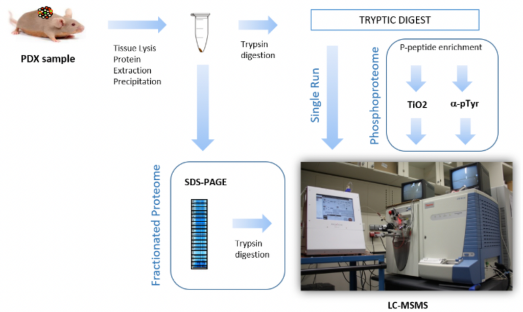

##### **2.1 ¿Qué aspectos del diseño experimental podrían haber influido en la interpretación de los resultados?**

En este estudio, se seleccionaron modelos de xenoinjertos derivados de pacientes (PDX) para MSS y PD, los cuales reflejan fielmente las características del tumor humano, pero presentan una variabilidad biológica intrínseca. Además, se emplearon métodos de enriquecimiento de fosfopéptidos (TiO₂ y α-pTyr), que aunque altamente específicos, pueden introducir sesgos al focalizar el análisis únicamente en rutas dependientes de fosforilación, dejando fuera otros procesos moleculares relevantes.

Factores como el batch effect (efectos de lote) y la variabilidad técnica entre réplicas también pudieron influir en las diferencias observadas. Para mitigar estas limitaciones, se implementaron controles técnicos rigurosos y se utilizaron estrategias estadísticas avanzadas, como ajustes con el paquete `limma`, para garantizar que las diferencias detectadas fueran biológicamente significativas y no el resultado de artefactos técnicos.

##### **2.2 ¿Qué tipo de diseño experimental utilizaron los investigadores?**

El diseño experimental fue un análisis comparativo entre los subtipos tumorales MSS y PD, utilizando xenoinjertos derivados de pacientes (PDX) como modelo experimental. Este diseño incluyó réplicas biológicas para capturar la variabilidad intrínseca de los tumores y réplicas técnicas para controlar la variabilidad introducida durante el procesamiento de muestras. Cada grupo fue representado por tres muestras, procesadas en dos réplicas técnicas, generando un total de doce mediciones.

Los datos obtenidos fueron preprocesados mediante normalización logarítmica y ajustes estadísticos para mitigar efectos técnicos, como el batch effect.

##### **2.3 ¿Por qué se eligieron específicamente los modelos de xenoinjertos derivados de pacientes (PDX) como el modelo experimental para MSS y PD?**

Los modelos de xenoinjertos derivados de pacientes (PDX) fueron elegidos porque reproducen con alta fidelidad las características genéticas, fenotípicas y del microambiente tumoral humano, incluidas las modificaciones postraduccionales como la fosforilación. Estos modelos permiten conservar la heterogeneidad y propiedades moleculares del tumor original, proporcionando una base experimental más relevante para estudiar las diferencias biológicas entre MSS y PD en comparación con modelos in vitro o animales.

Además, replican de manera más precisa las interacciones tumorales en un entorno fisiológicamente relevante, lo que los convierte en una herramienta valiosa para analizar las diferencias moleculares específicas de cada subtipo tumoral. No obstante, su uso también introduce cierta variabilidad biológica intrínseca, que debe ser considerada al interpretar los resultados del análisis.

##### **2.4 ¿Cuáles son las ventajas y limitaciones de la selección y el enriquecimiento de fosfopéptidos utilizando métodos como TiO2 y α-pTyr?**

El enriquecimiento de fosfopéptidos mediante métodos como TiO₂ y α-pTyr ofrece importantes ventajas al permitir la detección específica de fosfopéptidos fosforilados en serinas, treoninas y tirosinas, respectivamente. Esto mejora significativamente la sensibilidad y especificidad en la identificación de modificaciones de fosforilación clave, facilitando el análisis de rutas de señalización relevantes y la identificación de posibles biomarcadores.

Sin embargo, estos métodos también tienen limitaciones. Su alta selectividad puede excluir fosfopéptidos menos abundantes o con sitios de fosforilación menos representados, introduciendo un sesgo hacia aquellos con mayor afinidad al método de enriquecimiento. Esto podría restringir el análisis a rutas dependientes de fosforilación, dejando fuera otras modificaciones postraduccionales relevantes en el contexto del cáncer.

##### **2.5 ¿Cómo se controló la variabilidad experimental?**

La variabilidad experimental se controló mediante el uso de réplicas técnicas y biológicas. Cada muestra fue procesada en dos réplicas técnicas para evaluar y ajustar las diferencias introducidas por la instrumentación y el procesamiento. Además, se incluyeron réplicas biológicas para capturar la heterogeneidad intrínseca de los subtipos MSS y PD, asegurando que los resultados representen de manera confiable las características moleculares de cada grupo.

En el análisis estadístico, se aplicaron ajustes como duplicateCorrelation del paquete limma, normalización logarítmica y normalización cuantílica (quantile normalization). Este último método garantiza que las distribuciones de abundancia de los fosfopéptidos sean comparables entre muestras, minimizando sesgos técnicos y asegurando que las diferencias observadas reflejen variaciones biológicas reales. Estas estrategias conjuntas permitieron obtener resultados más robustos y reproducibles.

Además de las estrategias ya mencionadas, se realizaron mapas de calor de valores perdidos y gráficos de boxplot antes y después de la normalización para evaluar la calidad inicial de los datos y confirmar que la normalización era efectiva en reducir la variabilidad técnica.

##### **2.6 ¿Se han considerado efectos de batch o factores técnicos adicionales que puedan influir en las diferencias observadas entre MSS y PD?**

Sí, se consideraron efectos de lote (batch effects) y factores técnicos adicionales que pudieran influir en las diferencias observadas entre MSS y PD. Para mitigar estos efectos, se implementaron controles estadísticos como `arrayWeights` y `duplicateCorrelation` del paquete `limma`, que permiten ajustar las variaciones técnicas y las réplicas, minimizando el impacto de artefactos experimentales en los datos.

Además, se aplicaron transformaciones logarítmicas y normalización cuantílica para garantizar una distribución comparable de las abundancias entre muestras y reducir el ruido técnico.

Asimismo, se realizaron análisis exploratorios previos como PCA para detectar posibles artefactos relacionados con efectos de batch. Estos análisis permitieron evaluar si había sesgos significativos introducidos por factores técnicos, antes de aplicar las correcciones estadísticas mencionadas. Este paso preliminar asegura que las estrategias de normalización y ajuste se aplicaran de manera adecuada al contexto experimental.

Estas estrategias aseguran que las diferencias observadas entre MSS y PD sean biológicamente significativas y no un producto de efectos técnicos o de lote.

#### **3. Cuestiones Relacionadas con la Obtención de Datos Crudos y Métodos de Análisis**

##### **3.1 ¿Cómo afecta la técnica de espectrometría de masas en tándem (LC-MS/MS) a la precisión y sensibilidad en la detección de fosfopéptidos en los subtipos tumorales?**

La espectrometría de masas en tándem (LC-MS/MS), combinada con fragmentación por colisión (CID o HCD), fue clave para la detección y cuantificación precisa de fosfopéptidos en este estudio. Estas configuraciones permitieron identificar modificaciones de fosforilación en proteínas con alta sensibilidad, logrando una resolución suficiente para distinguir diferencias significativas entre MSS y PD. Además, el uso de métodos de enriquecimiento selectivo como TiO₂ y α-pTyr mejoró la cobertura de fosfopéptidos fosforilados, facilitando el análisis de rutas de señalización clave.

No obstante, LC-MS/MS tiene limitaciones inherentes, como el sesgo hacia péptidos más abundantes y aquellos con mayor afinidad al método de enriquecimiento. Esto puede llevar a una representación incompleta de los fosfopéptidos presentes en las muestras. Estas limitaciones se mitigaron mediante controles técnicos, como la calibración de los espectrómetros para minimizar el ruido, y mediante ajustes estadísticos que garantizaron que las diferencias detectadas fueran representativas y confiables.

##### **3.2 ¿Qué tipo de preprocesamiento o normalización se aplicó a los datos para obtener una abundancia normalizada fiable?**

El preprocesamiento de los datos incluyó múltiples pasos para garantizar su calidad y comparabilidad. Inicialmente, se realizaron mapas de calor para detectar valores faltantes y gráficos de boxplots para evaluar la consistencia en las distribuciones entre muestras. Los datos se transformaron logarítmicamente (log10) para estabilizar la varianza, reducir el impacto de valores extremos y mejorar la comparabilidad.

Posteriormente, se aplicó normalización cuantílica (quantile normalization), asegurando que las distribuciones de abundancia fueran homogéneas entre muestras y reduciendo posibles sesgos técnicos. Como parte del análisis estadístico, se utilizó la función duplicateCorrelation del paquete limma para ajustar las réplicas técnicas y corregir efectos técnicos adicionales. Antes de proceder con el análisis diferencial, se realizaron análisis exploratorios, como PCA, para confirmar que el preprocesamiento y la normalización eran efectivos, lo que garantizó que las diferencias detectadas reflejaran variaciones biológicas reales.

##### **3.3 ¿Cómo se seleccionaron los fosfopéptidos para el análisis estadístico, se aplicaron criterios específicos para la inclusión o exclusión de datos?**

Adicionalmente, se consideraron gráficos de Volcano Plots y resúmenes descriptivos como herramientas de validación para confirmar la relevancia de los fosfopéptidos seleccionados. Aunque no se aplicaron filtros adaptativos para excluir valores de baja intensidad, la transformación logarítmica fue suficiente para estabilizar la variabilidad extrema sin eliminar fosfopéptidos potencialmente relevantes. Este enfoque permitió identificar un conjunto clave de fosfopéptidos diferencialmente abundantes entre MSS y PD, esenciales para los análisis funcionales y la identificación de biomarcadores.

A continuación, implementamos el código organizado y comentado para responder a cada pregunta.

##### **Importación de datos y carga de paquetes**

La carga y configuración de los paquetes es un paso esencial para asegurar que todas las herramientas necesarias están disponibles y listas para su uso. Estos paquetes ofrecen funcionalidades específicas para la manipulación, análisis y visualización de datos ómicos.

##### **Importación y Preprocesado de los Datos**

Este bloque se enfoca en la preparación de datos para el análisis, un paso previo a cualquier selección de fosfopéptidos.

En esta sección se importan los datos de fosfopéptidos y se estructura la matriz de abundancias como paso preliminar al análisis diferencial entre los grupos MSS y PD. Este bloque establece la base para abordar las cuestiones relacionadas con la normalización y selección de fosfopéptidos, que serán detalladas en secciones posteriores.

Este paso es crucial para establecer las bases del análisis estadístico, ya que asegura que los datos están correctamente formateados. Aunque aquí no se aplican técnicas específicas de normalización o selección de datos, estos procesos se desarrollarán en las secciones dedicadas al preprocesamiento y análisis estadístico.

Cargamos los datos desde el repositorio de GitHub y realizamos una comprobación visual y estructural para entender su composición.

```
## # A tibble: 6 × 18
##   SequenceModifications    Accession Description Score M1_1_MSS M1_2_MSS M5_1_MSS M5_2_MSS T49_1_MSS
##   <chr>                    <chr>     <chr>       <dbl>    <dbl>    <dbl>    <dbl>    <dbl>     <dbl>
## 1 LYPELSQYMGLSLNEEEIR[2] … O00560    Syntenin-1…  48.1     24.3   44476.       0     6269.     1136.
## 2 VDKVIQAQTAFSANPANPAILSE… O00560    Syntenin-1…  67.0      0     43139.    2102.   50355.      249.
## 3 VIQAQTAFSANPANPAILSEASA… O00560    Syntenin-1…  77.7   3413.   172143.   77323.  307637.    98442.
## 4 HADAEMTGYVVTR[6] Oxidat… O15264    Mitogen-ac…  44.9 220431.   145657.  104288.   75887.   773377.
## 5 HADAEMTGYVVTR[9] Phospho O15264    Mitogen-ac…  67.4  18255.     8530.   35956.   44102.    57145.
## 6 STGPGASLGTGYDR[12] Phos… O15551    Claudin-3 …  63.7 644513.   261938.  187023.  124868.  4487444.
## # ℹ 9 more variables: T49_2_MSS <dbl>, M42_1_PD <dbl>, M42_2_PD <dbl>, M43_1_PD <dbl>,
## #   M43_2_PD <dbl>, M64_1_PD <dbl>, M64_2_PD <dbl>, CLASS <chr>, PHOSPHO <chr>
```

```
## # A tibble: 6 × 4
##   Sample...1 Sample...2 Individual Phenotype
##   <chr>      <chr>           <dbl> <chr>
## 1 M1_1       M1                  1 MSS
## 2 M1_2       M1                  1 MSS
## 3 M5_1       M5                  2 MSS
## 4 M5_2       M5                  2 MSS
## 5 T49_1      T49                 3 MSS
## 6 T49_2      T49                 3 MSS
```

##### **Preparación de los Metadatos y Datos Principales**

En este apartado se prepara la matriz de abundancias y los metadatos de las muestras como paso previo al análisis estadístico. Aunque no se seleccionan ni filtran fosfopéptidos, este bloque organiza la información de manera que sea posible abordar cuestiones relacionadas con la variabilidad experimental, el diseño experimental y la selección de biomarcadores en análisis posteriores.

Los datos principales corresponden a las abundancias normalizadas de señales MS y los metadatos incluyen las etiquetas de muestra y grupo.

##### **Creación del Objeto SummarizedExperiment**

`SummarizedExperiment` es una estructura de datos ideal para estudios ómicos, integrando la matriz de abundancias con los metadatos de cada muestra. Este formato facilita la manipulación y el análisis de datos, ya que permite aplicar métodos estadísticos directamente sobre el objeto estructurado.

```
## class: SummarizedExperiment
## dim: 1438 12
## metadata(0):
## assays(1): counts
## rownames(1438): O00560 O00560.1 ... Q13283.1 Q9NYF8.12
## rowData names(4): Accession SequenceModifications Description Score
## colnames(12): M1_1 M1_2 ... M64_1 M64_2
## colData names(5): sample Sample...2 individual group replicate
```

**Interpretación de los resultados**

La creación del objeto `SummarizedExperiment` parece haber funcionado correctamente. Este paso asegura que nuestros datos están listos para los análisis estadísticos y visualización en los próximos apartados.

Aquí tienes una interpretación siguiendo el estilo que prefieres:

1. **Dimensiones (`dim`)**: Indica `1438 x 12`, lo que significa que tenemos 1438 filas (representando fosfopéptidos) y 12 columnas (correspondientes a las muestras), capturando así la cantidad total de datos que esperábamos para el análisis.
2. **Assays (`assays`)**: Contiene `counts`, confirmando que la matriz de abundancias de los fosfopéptidos se ha almacenado correctamente como el dato principal en el objeto `SummarizedExperiment`.
3. **Nombres de Filas (`rownames`)**: Los nombres de las 1438 filas corresponden a identificadores únicos de cada fosfopéptido, lo que asegura una referencia clara y sin duplicados para cada entrada.
4. **Datos de las Filas (`rowData`)**: Incluye 4 atributos (`Accession`, `SequenceModifications`, `Description`, `Score`) que proporcionan información descriptiva adicional para cada fosfopéptido, útil para análisis detallados y referencias cruzadas en bases de datos.
5. **Nombres de Columnas (`colnames`)**: Contiene los nombres de las muestras (`M1_1`, …, `M64_2`), asegurando que cada columna en la matriz de abundancia esté correctamente asociada a su muestra correspondiente.
6. **Metadatos de las Columnas (`colData`)**: Contiene 5 atributos (`sample`, `Sample...2`, `individual`, `group`, `replicate`) que describen las características experimentales de cada muestra, como su grupo (`MSS` o `PD`), individuo al que pertenece y número de réplica, lo cual es fundamental para los análisis estadísticos y de variabilidad.

Este código es óptimo para preparar datos de fosfoproteómica para análisis estadísticos y de enriquecimiento porque estructura de manera integrada las abundancias, los metadatos y la información descriptiva de los fosfopéptidos en un objeto `SummarizedExperiment`. Esto facilita el uso de herramientas de Bioconductor, como `limma` para análisis diferencial y bases de datos como KEGG o PhosphoSitePlus para análisis de enriquecimiento, asegurando una gestión de datos eficiente y una compatibilidad total con los flujos de trabajo bioinformáticos avanzados.

#### **4. Cuestiones sobre el Control de Calidad y Preprocesado de Datos**

Este apartado tiene como objetivo asegurar la calidad e integridad de los datos antes del análisis estadístico. Aquí abordamos varias cuestiones clave:

##### **4.1 ¿Cuáles pueden ser los posibles desafíos relacionados con la calidad de los datos crudos?**

Los datos crudos obtenidos mediante LC-MS/MS presentan desafíos clave:

- **Valores faltantes:** Comunes debido a límites de detección en el espectrómetro o variaciones en el enriquecimiento de fosfopéptidos.
- **Ruido técnico y valores extremos:** Introducidos por discrepancias en el procesamiento experimental y la sensibilidad de los instrumentos.
- **Distribuciones asimétricas:** Con abundancias sesgadas hacia niveles bajos de detección, complicando la comparación entre muestras.
- **Batch effects:** Efectos de lote que pueden introducir variaciones no biológicas entre corridas experimentales.

**Cómo se abordó en el código:**

- Se generaron **mapas de calor** para detectar patrones de valores faltantes y evaluar su impacto.
- Boxplots e histogramas identificaron valores extremos y distribuciones asimétricas, justificando la necesidad de transformaciones logarítmicas y normalización.
- Se emplearon **análisis PCA** preliminares para detectar posibles efectos técnicos o de lote antes de continuar con los análisis diferenciales.

##### **4.2 ¿Qué ajustes o preprocesados serían razonables para abordar estos desafíos?**

Se implementaron ajustes y preprocesados específicos para garantizar la calidad de los datos:

**Cómo se implementó en el código:**

- Se utilizaron funciones como `log10` para transformar los datos y `normalize.quantiles` para realizar la normalización cuantílica.
- Los boxplots se utilizaron para validar la efectividad de los ajustes.
- Se realizó PCA con `prcomp` para verificar que las diferencias observadas fueran biológicas y no resultado de artefactos técnicos.

##### **4.3 ¿Cómo se controló la variabilidad experimental con las réplicas técnicas?**

El control de la variabilidad experimental incluyó:

- **Réplicas técnicas:** Cada muestra fue procesada en dos réplicas técnicas para evaluar y corregir inconsistencias instrumentales.
- **Ajustes estadísticos:** Se utilizó la función `duplicateCorrelation` del paquete `limma` para modelar la correlación entre réplicas técnicas y ajustar su impacto en los modelos lineales.
- **Evaluaciones visuales:** Boxplots y análisis PCA antes y después de la normalización garantizaron que las réplicas técnicas fueran consistentes y los datos fiables.

**Cómo se implementó en el código:**

- `duplicateCorrelation` se utilizó en el diseño estadístico para ajustar las diferencias entre réplicas técnicas.
- Boxplots confirmaron la consistencia entre réplicas antes y después de la normalización.
- PCA validó que las réplicas técnicas no introducían sesgos significativos en los datos finales.

##### **Resumen estadístico de los datos de abundancia**

Comenzamos con un resumen estadístico de las abundancias para entender el rango de valores y la estructura general de los datos.

```
##       M1_1               M1_2               M5_1               M5_2              T49_1
##  Min.   :       0   Min.   :       0   Min.   :       0   Min.   :       0   Min.   :       0
##  1st Qu.:    5653   1st Qu.:    5497   1st Qu.:    2573   1st Qu.:    3273   1st Qu.:    9306
##  Median :   30682   Median :   26980   Median :   20801   Median :   26241   Median :   55641
##  Mean   :  229841   Mean   :  253151   Mean   :  232967   Mean   :  261067   Mean   :  542449
##  3rd Qu.:  117373   3rd Qu.:  113004   3rd Qu.:  113958   3rd Qu.:  130132   3rd Qu.:  223103
##  Max.   :16719906   Max.   :43928481   Max.   :15135169   Max.   :19631820   Max.   :49218872
##      T49_2              M42_1              M42_2              M43_1              M43_2
##  Min.   :       0   Min.   :       0   Min.   :       0   Min.   :       0   Min.   :       0
##  1st Qu.:    8611   1st Qu.:    5341   1st Qu.:    4216   1st Qu.:   19641   1st Qu.:   17299
##  Median :   46110   Median :   36854   Median :   30533   Median :   67945   Median :   59607
##  Mean   :  462616   Mean   :  388424   Mean   :  333587   Mean   :  349020   Mean   :  358822
##  3rd Qu.:  189141   3rd Qu.:  180252   3rd Qu.:  152088   3rd Qu.:  205471   3rd Qu.:  201924
##  Max.   :29240206   Max.   :48177680   Max.   :42558111   Max.   :35049402   Max.   :63082982
##      M64_1              M64_2
##  Min.   :       0   Min.   :       0
##  1st Qu.:   11038   1st Qu.:    8660
##  Median :   52249   Median :   47330
##  Mean   :  470655   Mean   :  484712
##  3rd Qu.:  209896   3rd Qu.:  206036
##  Max.   :71750330   Max.   :88912734
```

```
## [1] 1438   12
```

Este bloque proporciona una visión general de la distribución de las abundancias y permite identificar rangos amplios, valores fuera de lo esperado y sesgos que podrían influir en el análisis posterior.

**Interpretación de los resultados**

El resumen estadístico mostró una gran variabilidad en las abundancias de fosfopéptidos entre las muestras, con algunos valores extremadamente altos en ciertas muestras (por ejemplo, algunas del grupo PD). Esta variabilidad puede estar relacionada con diferencias en los niveles de fosforilación entre los subtipos tumorales MSS y PD. Dado que el objetivo es identificar diferencias en la fosforilación que permitan la caracterización entre subtipos, esta observación inicial indica que podrían existir fosfopéptidos específicos que diferencian estos grupos, justificando la realización de un análisis más profundo.

**Interpretación Detallada**

En general, las estadísticas descriptivas sugieren una alta variabilidad entre muestras y sugieren que los datos están sesgados hacia valores bajos, lo cual es común en proteómica y puede requerir normalización o transformación para un análisis posterior más profundo.

##### **Comprobación de valores nulos en los datos de fosfopéptidos**

```
##  M1_1  M1_2  M5_1  M5_2 T49_1 T49_2 M42_1 M42_2 M43_1 M43_2 M64_1 M64_2
##     0     0     0     0     0     0     0     0     0     0     0     0
```

Este paso verifica la presencia de valores nulos en el conjunto de datos. La ausencia de valores nulos indica que no es necesario realizar imputaciones.

##### **Visualización de valores nulos con un mapa de calor**

La visualización de valores nulos con un mapa de calor permite identificar rápidamente patrones de ausencia en grandes conjuntos de datos. Esto contribuye a la evaluación de la calidad de los datos crudos ayudando a decidir si hay problemas de integridad en los datos que deben solucionarse antes del análisis.

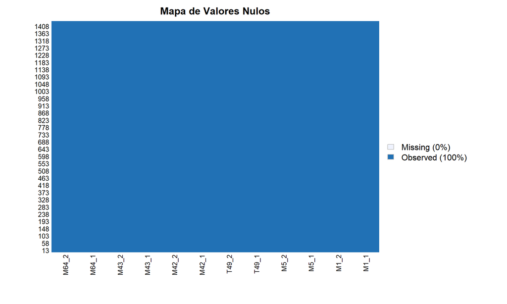

**Interpretación de los resultados**

La ausencia de valores nulos en las columnas de abundancia indica una buena calidad inicial de los datos (en este contexto), lo que significa que no es necesario realizar imputaciones de valores. Este control inicial es esencial para asegurar que los análisis estadísticos sean robustos y no se vean sesgados.

##### **Conversión de la matriz de abundancias a formato de DataFrame para visualización**

Esta transformación facilita el uso de `ggplot2` para la visualización de cada muestra individualmente.

##### **Generación de histogramas para visualizar la distribución de abundancias de fosfopéptidos en cada muestra**

Los histogramas permiten visualizar la distribución de abundancias por muestra y detectar sesgos o valores extremos.

Este análisis aborda la calidad de los datos crudos y prepara el terreno para el análisis diferencial, ayudando a entender la variabilidad intrínseca de las muestras.

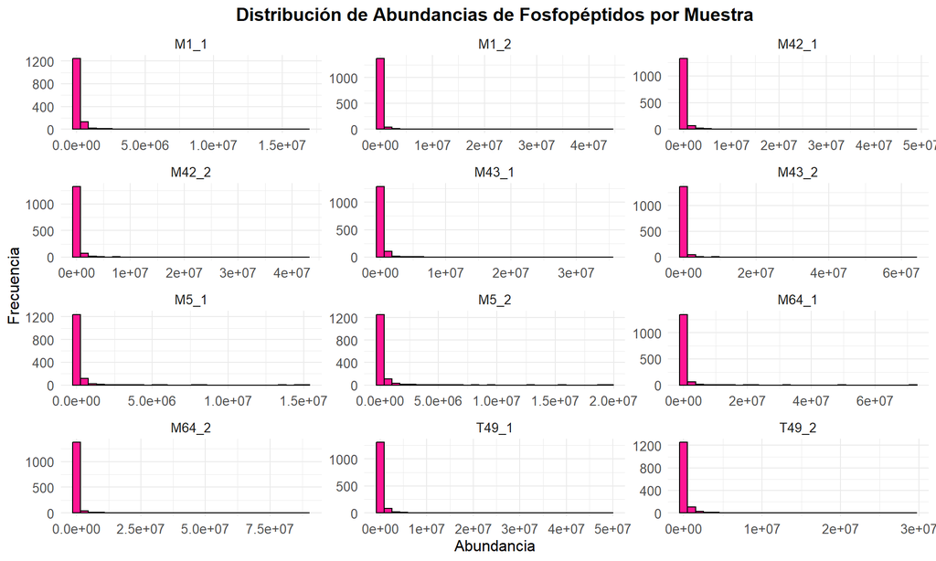

**Interpretación de los resultados**

Los histogramas muestran la distribución de las abundancias de fosfopéptidos en cada muestra. En general, observamos que las distribuciones son asimétricas, con la mayoría de los datos concentrados en el extremo inferior cercanos a cero. Esta distribución altamente sesgada es consistente en todas las muestras.

Asimismo, la presencia de fosfopéptidos con alta abundancia en ciertas muestras puede reflejar la activación de rutas específicas en estos tumores, lo cual es relevante para entender la señalización diferencial en los subtipos MSS y PD.

##### **Visualización de variabilidad con boxplots para cada muestra**

Los boxplots muestran la variabilidad de las abundancias entre muestras, resaltando outliers y diferencias en la dispersión. Esto responde a la cuestión sobre la variabilidad de las muestras y los posibles valores atípicos, ayudando a decidir si es necesario algún ajuste adicional.

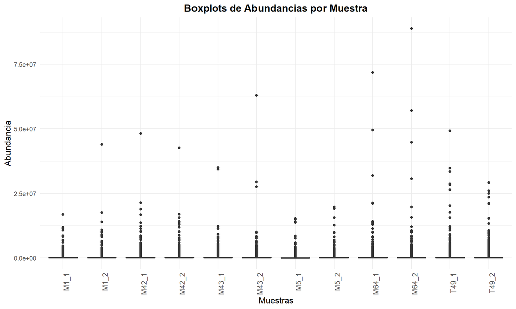

**Interpretación de los resultados**

Los boxplots destacan aún más el sesgo en los datos, con la mayoría de las muestras mostrando una distribución de valores comprimidos en la parte baja y múltiples outliers en el extremo superior.

Los outliers representan fosfopéptidos con abundancias mucho mayores que el resto, lo cual podría estar relacionado con proteínas especialmente activas o rutas diferenciadas en las muestras.

La variabilidad entre las muestras es notable, pero la mayoría de los valores se concentran cerca de cero, lo cual puede justificar una transformación logarítmica para reducir el impacto de estos valores extremos y visualizar mejor las diferencias entre muestras.

Este análisis inicial sugiere que los datos de abundancia necesitan un ajuste (como una transformación logarítmica) para mejorar la normalización y facilitar la interpretación en análisis posteriores.

##### **Transformación logarítmica para normalizar los datos y reducir la influencia de valores extremos**

Para reducir la influencia de valores extremos, aplicamos una transformación logarítmica a los datos de abundancia y generamos un nuevo gráfico de boxplot. Esto puede ayudar a visualizar y comparar mejor las diferencias entre las muestras. La transformación logarítmica suaviza las distribuciones y estabiliza la varianza, reduciendo el sesgo de los valores extremos y permitiendo una visualización más equitativa de las muestras. Este paso es crucial para abordar la cuestión de normalización de los datos.

```
## [1] 1438   12
```

```
##  [1] "M1_1"  "M1_2"  "M5_1"  "M5_2"  "T49_1" "T49_2" "M42_1" "M42_2" "M43_1" "M43_2" "M64_1" "M64_2"
```

```
##       M1_1            M1_2            M5_1            M5_2           T49_1           T49_2
##  Min.   :0.000   Min.   :0.000   Min.   :0.000   Min.   :0.000   Min.   :0.000   Min.   :0.000
##  1st Qu.:3.752   1st Qu.:3.740   1st Qu.:3.411   1st Qu.:3.515   1st Qu.:3.969   1st Qu.:3.935
##  Median :4.487   Median :4.431   Median :4.318   Median :4.419   Median :4.745   Median :4.664
##  Mean   :4.156   Mean   :4.095   Mean   :3.893   Mean   :4.050   Mean   :4.439   Mean   :4.329
##  3rd Qu.:5.070   3rd Qu.:5.053   3rd Qu.:5.057   3rd Qu.:5.114   3rd Qu.:5.349   3rd Qu.:5.277
##  Max.   :7.223   Max.   :7.643   Max.   :7.180   Max.   :7.293   Max.   :7.692   Max.   :7.466
##      M42_1           M42_2           M43_1           M43_2           M64_1           M64_2
##  Min.   :0.000   Min.   :0.000   Min.   :0.000   Min.   :0.000   Min.   :0.000   Min.   :0.000
##  1st Qu.:3.728   1st Qu.:3.625   1st Qu.:4.293   1st Qu.:4.238   1st Qu.:4.043   1st Qu.:3.938
##  Median :4.566   Median :4.485   Median :4.832   Median :4.775   Median :4.718   Median :4.675
##  Mean   :4.155   Mean   :4.073   Mean   :4.730   Mean   :4.695   Mean   :4.450   Mean   :4.382
##  3rd Qu.:5.256   3rd Qu.:5.182   3rd Qu.:5.313   3rd Qu.:5.305   3rd Qu.:5.322   3rd Qu.:5.314
##  Max.   :7.683   Max.   :7.629   Max.   :7.545   Max.   :7.800   Max.   :7.856   Max.   :7.949
```

**Interpretación de los resultados**

**Interpretación del Resumen Estadístico Tras la Transformación Logarítmica**

En resumen, la transformación logarítmica ha normalizado los datos, haciéndolos más adecuados para análisis estadísticos posteriores.

##### **Visualización de abundancias en escala logarítmica: Histogramas y Boxplots**

Agrupamos las réplicas de cada muestra con el mismo color para facilitar la visualización de la coherencia entre réplicas y distinguir las diferencias potenicales entre los grupos tumorales.

Los boxplots en escala logarítmica permiten una comparación uniforme entre muestras, eliminando el sesgo de los valores extremos, lo que asegura que la normalización es adecuada para el análisis diferencial y facilita la evaluación de la variabilidad y comparabilidad entre muestras.

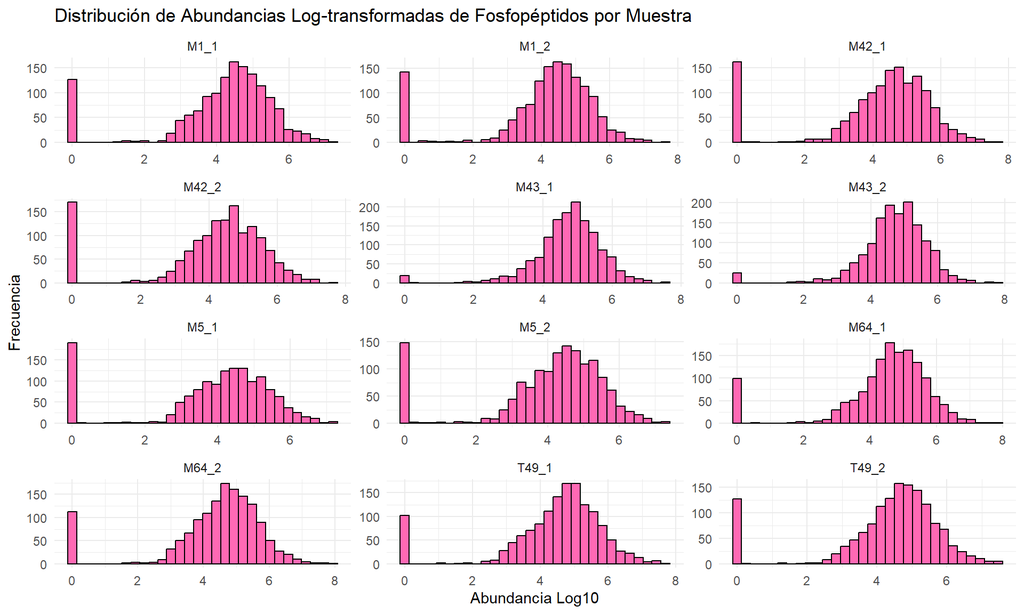

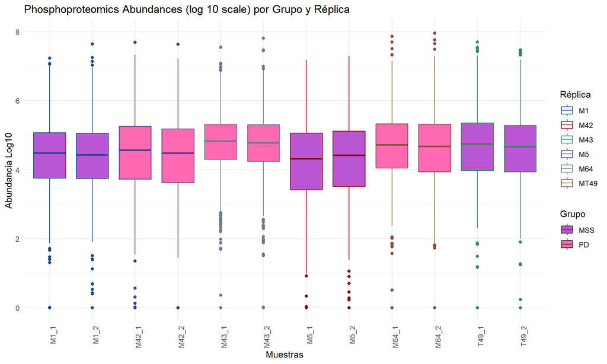

**Interpretación de los resultados**

**Distribución Normalizada (Histogramas):**  
La transformación logarítmica ha centralizado las abundancias de fosfopéptidos alrededor de valores medios (entre 3 y 7 en la escala logarítmica), reduciendo la variabilidad extrema y la asimetría. Esto facilita la comparación equitativa entre muestras, permitiendo identificar patrones más claros en los datos.

**Interpretación Biológica**

1. **Diferencias de Fosforilación entre MSS y PD:**  
   El grupo PD muestra mayor variabilidad en los niveles de fosforilación, lo que sugiere una regulación diferencial de vías específicas de señalización. Esto puede estar vinculado con el comportamiento más agresivo del subtipo PD.
2. **Identificación de Biomarcadores Potenciales:**  
   Las diferencias observadas sugieren que algunos fosfopéptidos podrían actuar como biomarcadores específicos de cada grupo. Identificar estos fosfopéptidos ayudaría a clasificar mejor a los pacientes y a predecir respuestas a tratamientos.

**Conclusión**

La exploración inicial y el control de calidad aseguran que los datos sean consistentes y estén listos para el análisis estadístico. Las visualizaciones y transformaciones permiten identificar patrones de variabilidad y garantizan que los datos tengan una distribución adecuada para las comparaciones entre los grupos MSS y PD. Este análisis también confirma que un filtro adaptativo no es necesario, ya que la transformación logarítmica es suficiente para normalizar la distribución de los datos sin perder información relevante en los fosfopeptidos de baja intensidad.

#### **5. Cuestiones sobre el Análisis Estadístico y la Identificación de Fosfopéptidos Diferenciales**

El objetivo de este apartado es realizar un análisis estadístico exhaustivo para identificar fosfopéptidos cuya abundancia pueda distinguir entre los subtipos tumorales MSS y PD. La estrategia incluye un análisis exploratorio inicial mediante PCA y, posteriormente, pruebas estadísticas específicas con el paquete limma. La selección de técnicas de normalización y escalado se basa en las observaciones realizadas en cada paso, buscando reducir la variabilidad técnica y mejorar la precisión de la detección. Podemos caracterizar nuestro proceso de análisis intentando dar respuesta a las siguientes preguntas:

##### **5.1 ¿Cómo se llevó a cabo el análisis estadístico? ¿Cuáles fueron los criterios utilizados para identificar fosfopéptidos que diferencian los grupos tumorales?**

El análisis estadístico comenzó con un **análisis exploratorio preliminar mediante PCA**, en el cual se observaron patrones de agrupación que sugerían diferencias en los perfiles de fosforilación entre los subtipos. En particular, se identificó una separación inicial entre MSS y PD, aunque el grupo PD mostró una mayor heterogeneidad interna, con la muestra M43 destacándose como un posible caso atípico.

Basándose en estos hallazgos preliminares, se procedió al análisis diferencial utilizando el paquete **`limma`**. Primero, se generó una **matriz de diseño** para definir las condiciones experimentales MSS y PD, y se estableció la comparación entre ambos subtipos mediante `makeContrasts`. Al analizar los resultados iniciales, los **Volcano Plots** revelaron una dispersión considerable en los datos, especialmente en PD, lo que evidenció la necesidad de una normalización adicional para reducir la variabilidad técnica y mejorar la precisión del análisis.

Con el objetivo de ajustar el modelo estadístico teniendo en cuenta esta muestra atípica, se utilizó **`arrayWeights`** en `limma`. Esta técnica asignó pesos adaptativos a las muestras en función de su contribución a la variabilidad total, reduciendo la influencia de M43 y otros posibles outliers, lo que permitió un ajuste más robusto y preciso en la identificación de fosfopéptidos diferencialmente abundantes.

**Criterios de selección:** - **FDR < 0.05:** Para controlar la tasa de descubrimiento falso, se aplicó el método de Benjamini-Hochberg durante la extracción de resultados con `topTable`, ajustando los p-valores para reducir la probabilidad de falsos positivos en las múltiples pruebas realizadas. - **log Fold Change ≥ |1|:** Indicativo de un cambio de al menos el doble o la mitad en la abundancia, considerado biológicamente relevante.

Finalmente, los **Volcano Plots** destacaron los fosfopéptidos con diferencias significativas y cambios biológicamente relevantes, identificando candidatos clave para análisis funcionales y estudios posteriores. Este enfoque integral garantizó un análisis estadístico robusto y confiable.

**5.1.1. Análisis de Componentes Principales (PCA)**

- **Objetivo**: El PCA es una herramienta exploratoria para observar la variabilidad global de los datos y detectar posibles patrones de agrupación que indiquen diferencias entre los grupos MSS y PD.
- **Procedimiento**: Aplicamos el PCA sobre los datos de abundancia de fosfopéptidos, previamente transformados logarítmicamente, lo cual reduce el impacto de valores extremos y estabiliza la varianza.
- **Visualización y Resultados**: Generamos un gráfico que muestra la distribución de las muestras en el espacio de los dos primeros componentes principales. Observamos si las muestras de MSS y PD forman grupos separados o si presentan patrones distintos.
- **Interpretación**: Una agrupación clara de las muestras MSS y PD en el espacio del PCA proporciona una primera indicación de que existen diferencias entre estos grupos, lo que justifica los análisis de significancia estadística posteriores para identificar fosfopéptidos que diferencian a estos subtipos tumorales.

Para simplificar el análisis utilizamos una función disponible en github para dibujar un gráfico de dispersión a partir de los resultados de un PCA.

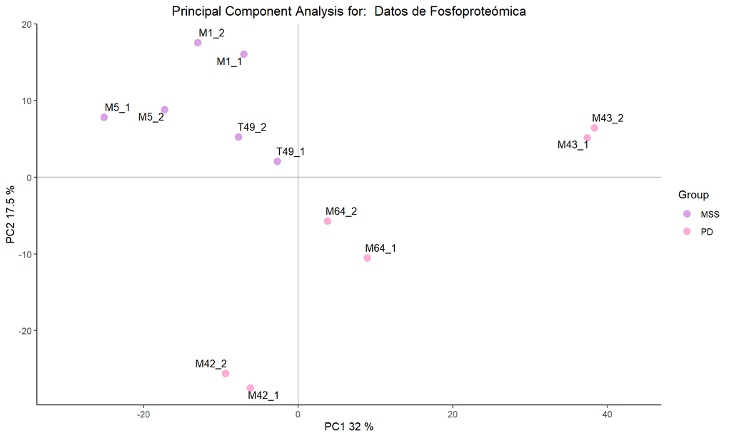

**Interpretación de los resultados**

El PCA en los datos de fosforilación muestra una clara separación entre los grupos MSS y PD en los primeros dos componentes principales (PC1 y PC2), lo cual sugiere patrones de fosforilación distintivos entre estos subtipos tumorales.

**Interpretación de los Componentes Principales (PC1 y PC2)**

**Observaciones por Grupo**

**5.1.2. Análisis de Diferencias entre Grupos con `limma`**

- **Preparación del Diseño Experimental**: Creamos una matriz de diseño que asigna cada muestra a su grupo correspondiente (MSS o PD) y aplicamos `duplicateCorrelation` para ajustar la variabilidad técnica asociada a las réplicas.
- **Definición de Comparaciones y Contrastes**: Definimos un contraste para comparar los grupos PD vs. MSS, permitiendo a `limma` evaluar las diferencias en la abundancia de fosfopéptidos entre estos subtipos tumorales.
- **Ajuste del Modelo y Cálculo de Significancia**: Ajustamos el modelo estadístico con `eBayes`, que aplica un ajuste Bayesiano para estabilizar las estimaciones de variabilidad y aumentar la robustez del análisis. Utilizamos un p-valor ajustado (tasa de descubrimiento falso, FDR) y un log Fold Change como criterios para identificar fosfopéptidos diferencialmente abundantes entre los grupos.
- **Criterios de Identificación**: Fosfopéptidos con un log Fold Change significativo (positivo o negativo) y un p-valor ajustado inferior a un umbral predefinido (0.05) se consideran diferencialmente abundantes. Estos criterios aseguran que los fosfopéptidos identificados no solo son estadísticamente significativos sino que también tienen una magnitud de cambio que es biológicamente relevante.
- **Visualización de Resultados**: Utilizamos un Volcano Plot para visualizar los fosfopéptidos que tienen cambios significativos en la abundancia entre los grupos MSS y PD, mostrando tanto el log Fold Change como el p-valor.

**Preparación del Diseño Experimental**

El análisis estadístico con `limma` requiere la creación de una matriz de diseño que asigne las muestras a los grupos experimentales (MSS y PD). Esto permite modelar el efecto de grupo en la abundancia de los fosfopéptidos.

```
##    MSS PD
## 1    1  0
## 2    1  0
## 3    1  0
## 4    1  0
## 5    1  0
## 6    1  0
## 7    0  1
## 8    0  1
## 9    0  1
## 10   0  1
## 11   0  1
## 12   0  1
## attr(,"assign")
## [1] 1 1
## attr(,"contrasts")
## attr(,"contrasts")$groups
## [1] "contr.treatment"
```

**Corrección de Réplicas Técnicas con `duplicateCorrelation`**

Para tener en cuenta las réplicas técnicas (ya que cada muestra se analizó por duplicado), aplicamos `duplicateCorrelation` para estimar y corregir la correlación entre réplicas en el modelo estadístico. Esto permite modelar de manera más fiel las diferencias reales entre los subtipos tumorales, evitando el ruido técnico.

```
## [1] 0.8182436
```

**Interpretación de los resultados**

La correlación de **0.818** entre réplicas técnicas indica una alta consistencia y buena reproducibilidad en las mediciones. Este valor permite que `limma` ajuste eficazmente las diferencias técnicas, enfocándose en variaciones biológicas reales entre los grupos `MSS` y `PD`, y aumentando la confiabilidad del análisis diferencial.

**Definición de Comparaciones con la Matriz de Contrastes**

La matriz de contraste (`contrast_matrix`) define la comparación PD vs. MSS, permitiendo que `limma` evalúe las diferencias en los niveles de fosfopéptidos entre estos dos grupos.

Mediante este paso definimos las comparaciones necesarias para detectar fosfopéptidos diferencialmente abundantes entre MSS y PD.

```
##       Contrasts
## Levels PD_vs_MSS
##    MSS        -1
##    PD          1
```

**Interpretación de los resultados**

El valor `1` asignado a `PD` y `-1` a `MSS` indica que el análisis identificará los fosfopéptidos con diferencias en la abundancia entre estos grupos, donde los valores positivos reflejarán mayor abundancia en `PD` y los negativos en `MSS`.

**Ajuste del Modelo y Pruebas de Significación con `limma`**

Aplicamos el modelo lineal y ajustamos las comparaciones para obtener un análisis de las diferencias significativas en la abundancia de fosfopéptidos.

Para asegurar que las diferencias observadas no son el resultado del azar, se utilizó la corrección por FDR aplicando el método de **Benjamini-Hochberg** (realizado en el paso con `topTable`). Este ajuste controla la proporción de falsos positivos, asegurando una mayor confiabilidad en los fosfopéptidos identificados.

El análisis con `eBayes` aplicado al modelo ajustado permite calcular p-valores y fold changes para cada fosfopéptido entre PD y MSS, aplica un ajuste bayesiano a los errores estándar del modelo mejorando la precisión de los resultados. El ajuste de p-valores (Benjamini-Hochberg) controla el error de falso descubrimiento, proporcionando una lista de fosfopéptidos que presentan cambios significativos entre los grupos.

```
##              logFC  AveExpr         t      P.Value    adj.P.Val         B
## Q9P206.1 4.4012388 2.200619 16.169208 3.747612e-09 5.389065e-06 9.3023053
## Q5SW79   2.8285404 1.414270  8.537658 2.956355e-06 2.125620e-03 4.7158022
## O60885   2.9732203 2.464315  4.960979 3.976350e-04 8.495224e-02 0.3876207
## P04075   1.0410814 4.599142  4.899029 4.394543e-04 8.495224e-02 0.2945831
## Q9NQ84.6 0.7826475 5.906159  4.813645 5.048377e-04 8.495224e-02 0.1653501
## Q86SQ4   1.3867065 4.095549  4.809415 5.083319e-04 8.495224e-02 0.1589181
```

**Interpretación de los resultados**

Los resultados del análisis son una tabla donde las proteínas, se ordenan de mayor a menor expresión diferencial según los resultados de la comparación realizada.

**Interpretación Estadística**

El resumen del análisis con Limma muestra una tabla de los fosfopéptidos más diferencialmente abundantes, con columnas para `logFC` (cambio en el logaritmo de la expresión), `AveExpr` (expresión promedio), `t`, `P.Value`, `adj.P.Val` (valor p ajustado), y `B`:

- **logFC**: Indica el cambio en la abundancia de cada fosfopéptido entre PD y MSS (representa el cambio de expresión en logaritmo base 2 (log fold-change)). Valores positivos sugieren mayor abundancia en el grupo PD en comparación con MSS, mientras que un valor negativo reflejaría lo contrario.
- **AveExpr**: Es la expresión promedio del fosfopéptido en todos los grupos, indicando el nivel medio de abundancia.
- **t**: Valor t del test estadístico, que indica la magnitud de la diferencia relativa a la variabilidad.
- **P.Value** y **adj.P.Val**: Representan la significancia estadística de los cambios observados. Valores de `adj.P.Val` bajos indican diferencias significativas en la abundancia entre los grupos, siendo estos fosfopéptidos candidatos a biomarcadores.
- **B-value**: Proporciona una medida de la probabilidad logarítmica de que el fosfopéptido sea diferencialmente expresado. Cuanto mayor sea el B-value, mayor es la confianza en que ese fosfopéptido presenta una diferencia significativa en abundancia entre MSS y PD.

**Interpretación Biológica**

- **Fosfopéptidos con altos valores de logFC y significancia estadística**: Los fosfopéptidos con los valores de |logFC| más altos y los p-valores ajustados más bajos son candidatos para investigaciones futuras, ya que probablemente representan biomarcadores de los subtipos tumorales o proteínas involucradas en vías de señalización diferencialmente activas entre los dos grupos.
- **Significado Biológico del logFC**: Se suele considerar un cambio de abundancia biológicamente relevante cuando el |logFC| es mayor a 1, lo que indica al menos un cambio de dos veces en la abundancia entre grupos. Este umbral ayuda a identificar fosfopéptidos con cambios de abundancia que pueden tener implicaciones funcionales importantes en los procesos tumorales.

**Visualización de Resultados: Volcano Plot**

El **Volcano Plot** visualiza los fosfopéptidos diferencialmente abundantes en un solo gráfico, facilitando la identificación de aquellos que tienen cambios significativos tanto en términos de fold change como de p-valor. Los puntos alejados de los ejes indican fosfopéptidos con cambios biológicamente relevantes (log fold change alto) y estadísticamente significativos (p-valor bajo), que son los más prometedores como biomarcadores de los subtipos tumorales.

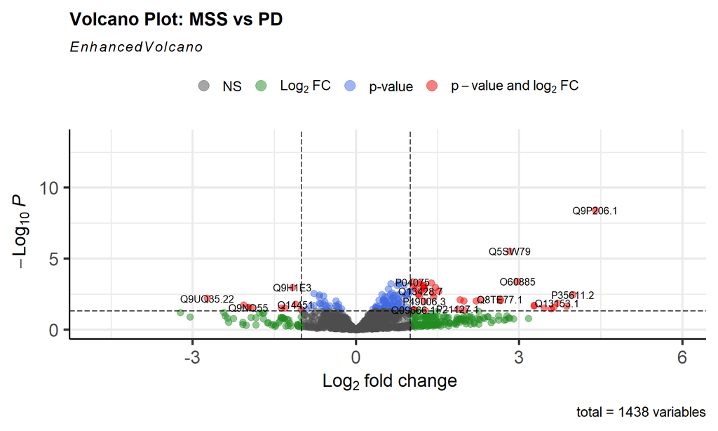

**Interpretación de los resultados**

El Volcano Plot muestra la relación entre la magnitud de cambio (log2 fold change) y la significancia estadística (-log10 p-value) de cada fosfopéptido al comparar los subtipos tumorales MSS y PD.

1. **Ejes**:
   - **Eje X (log2 fold change)**: Representa la magnitud de cambio en la abundancia de los fosfopéptidos entre MSS y PD. Valores positivos indican una mayor abundancia en el grupo PD, mientras que valores negativos reflejan una mayor abundancia en MSS.
   - **Eje Y (-log10 p-value)**: Indica la significancia estadística. Los puntos más altos en este eje representan fosfopéptidos con p-valores más bajos (es decir, mayor significancia).
2. **Color de los Puntos**:
   - Los puntos **rojos** destacan fosfopéptidos que presentan diferencias significativas en ambas dimensiones: tanto en el cambio de abundancia (log2 FC) como en la significancia estadística.
   - Los puntos **azules** y **verdes** representan fosfopéptidos que alcanzan significancia en sólo una de las dimensiones (p-value o log2 fold change), mientras que los puntos **grises** no alcanzan los umbrales de significancia en ninguna de las dos.
3. **Fosfopéptidos Significativos**:
   - Algunos fosfopéptidos, como aquellos etiquetados (Q9P206.1, Q5SW79, etc.), se destacan como significativamente diferentes entre los grupos MSS y PD con un cambio de abundancia importante y p-valores bajos. Estos podrían ser candidatos interesantes para distinguir entre los dos subtipos tumorales.
   - Los fosfopéptidos que destacan como significativos en el Volcano Plot están presentes en ambos subtipos tumorales (MSS y PD) pero muestran niveles de fosforilación diferentes entre los grupos.
4. **Distribución y Variabilidad**:
   - La dispersión considerable de puntos sugiere una variabilidad, posiblemente de origen técnico o biológico, que podría estar enmascarando diferencias sutiles entre grupos. La revisión de la normalización y el escalado podría ayudar a reducir esta variabilidad, permitiendo que los fosfopéptidos con diferencias importantes se destaquen más claramente.

**5.1.3. Evaluación de la Normalización: Resumen Estadístico y Dispersión**

A pesar de la transformación logarítmica inicial, el análisis de PCA y `limma` reveló una alta variabilidad en las muestras de PD, lo que podría complicar la identificación precisa de fosfopéptidos diferenciales. Este hallazgo justificó la aplicación de una normalización adicional.

Al analizar el resumen estadístico de los datos log-transformados, observamos que, aunque la transformación mejoró la homogeneidad, persistía una variabilidad notable, especialmente en los cuartiles y valores máximos del grupo PD. Para reducir esta variabilidad técnica sin afectar las diferencias biológicas, se optó por **Quantile Normalization**, que homogeneiza las distribuciones de abundancia entre muestras y mejora su comparabilidad.

**Normalización de datos con Quantile Normalization**

Esta técnica ajusta las distribuciones de abundancia de todas las muestras para que sean comparables entre sí, eliminando así la variabilidad técnica sin afectar las relaciones relativas entre fosfopéptidos.

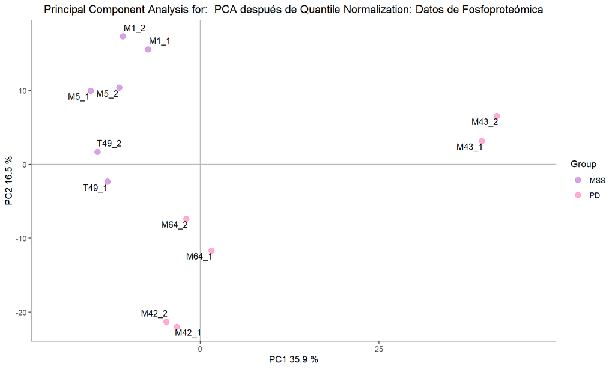

```
##       M1_1             M1_2             M5_1             M5_2            T49_1
##  Min.   :0.5099   Min.   :0.5325   Min.   :0.5651   Min.   :0.5369   Min.   :0.4709
##  1st Qu.:3.8489   1st Qu.:3.8489   1st Qu.:3.8489   1st Qu.:3.8489   1st Qu.:3.8489
##  Median :4.5930   Median :4.5930   Median :4.5930   Median :4.5930   Median :4.5930
##  Mean   :4.2867   Mean   :4.2754   Mean   :4.2177   Mean   :4.2703   Mean   :4.2934
##  3rd Qu.:5.2176   3rd Qu.:5.2176   3rd Qu.:5.2176   3rd Qu.:5.2176   3rd Qu.:5.2176
##  Max.   :7.5799   Max.   :7.5799   Max.   :7.5799   Max.   :7.5799   Max.   :7.5799
##      T49_2            M42_1            M42_2            M43_1           M43_2           M64_1
##  Min.   :0.5179   Min.   :0.5466   Min.   :0.5547   Min.   :0.000   Min.   :0.000   Min.   :0.468
##  1st Qu.:3.8489   1st Qu.:3.8489   1st Qu.:3.8489   1st Qu.:3.849   1st Qu.:3.849   1st Qu.:3.849
##  Median :4.5930   Median :4.5930   Median :4.5930   Median :4.593   Median :4.593   Median :4.593
##  Mean   :4.2862   Mean   :4.2593   Mean   :4.2461   Mean   :4.287   Mean   :4.287   Mean   :4.294
##  3rd Qu.:5.2176   3rd Qu.:5.2176   3rd Qu.:5.2176   3rd Qu.:5.218   3rd Qu.:5.218   3rd Qu.:5.218
##  Max.   :7.5799   Max.   :7.5799   Max.   :7.5799   Max.   :7.580   Max.   :7.580   Max.   :7.580
##      M64_2
##  Min.   :0.4814
##  1st Qu.:3.8489
##  Median :4.5930
##  Mean   :4.2910
##  3rd Qu.:5.2176
##  Max.   :7.5799
```

**Interpretación de los resultados**

**Interpretación del PCA tras la Quantile Normalization:**

La Quantile Normalization ha mejorado la comparabilidad entre las muestras y reducido el impacto de variabilidad técnica. Aunque M43 se mantiene algo alejada de las otras muestras PD, la distribución general es más homogénea, lo cual debería facilitar la identificación de diferencias biológicas significativas en el análisis estadístico posterior con limma. En análisis futuros, podría considerarse un tratamiento especial para M43 si continúa mostrando un comportamiento atípico, ya que su inclusión sin ajuste adicional podría influir en los resultados de comparación entre MSS y PD.

**Interpretación del Resumen Estadístico tras la Quantile Normalization:**

1. **Mediana uniforme en todas las muestras:** La mediana de las abundancias log-transformadas es exactamente la misma (4.593) para todas las muestras. Este es un efecto esperado de la normalización por cuantiles, que asegura que las distribuciones de las muestras sean comparables, lo cual ayuda a eliminar variaciones técnicas.
2. **Consistencia en los cuartiles y valores máximos:** Los valores del primer y tercer cuartil, así como los valores máximos, son prácticamente idénticos entre las muestras. Esto sugiere que la normalización ha ajustado las distribuciones de cada muestra para que tengan una variabilidad similar en términos de dispersión y rango, eliminando así las diferencias técnicas que no son biológicamente significativas.
3. **Disminución de la variabilidad técnica:** La homogeneidad en la distribución de las muestras indica que se ha reducido la variabilidad técnica observada previamente, especialmente en el grupo PD. Esta homogeneidad mejorará la precisión en la comparación de los fosfopéptidos entre los grupos MSS y PD en los análisis estadísticos posteriores.

**Observación sobre M43:** Aunque en el PCA la muestra M43 del grupo PD sigue mostrando un comportamiento ligeramente atípico, el resumen estadístico no presenta valores inusuales en comparación con otras muestras. Esto sugiere que la diferencia observada en el PCA podría estar relacionada con variabilidad biológica o características específicas de M43, más que con problemas técnicos.

La **Quantile Normalization** ha homogenizado las distribuciones de abundancia de los fosfopéptidos entre todas las muestras, facilitando comparaciones directas entre MSS y PD sin el sesgo de variabilidad técnica. Este ajuste debería permitir una identificación más precisa de fosfopéptidos diferencialmente abundantes en los análisis posteriores.

**5.1.4 Análisis Estadístico con limma y arrayWeights**

Para identificar fosfopéptidos diferencialmente abundantes entre MSS y PD, aplicamos `limma` tras la normalización por cuantiles. Aunque esta normalización redujo la variabilidad, el PCA aún mostraba que la muestra M43 en el grupo PD permanecía algo dispersa. Para ajustar este efecto, usamos `arrayWeights`, que asigna pesos adaptativos a las muestras, minimizando la influencia de aquellas con variabilidad residual. Este enfoque proporciona un análisis más robusto y permite detectar biomarcadores con mayor precisión.

```
##               logFC  AveExpr         t      P.Value    adj.P.Val        B
## Q9P206.1   3.386791 2.419242 12.772564 4.766759e-08 6.854599e-05 8.539915
## Q53RY4    -2.894041 2.189480 -8.834600 2.124214e-06 1.527310e-03 5.302703
## Q9UQ35.22 -3.386333 2.369327 -7.023290 1.945022e-05 8.040986e-03 3.245900
## Q12929    -1.000647 4.160975 -6.918536 2.236714e-05 8.040986e-03 3.113148
## Q5XXA6     2.508416 3.782184  6.568731 3.602977e-05 1.036216e-02 2.658059
## Q9H1C7     1.026968 5.337423  6.344868 4.929600e-05 1.064291e-02 2.357119
```

**Interpretación de los resultados**

La tabla muestra fosfopéptidos con diferencias significativas en abundancia entre los subtipos tumorales MSS y PD, calculados con `limma` y `arrayWeights` tras la normalización por cuantiles. A continuación, se destacan las columnas clave:

- **logFC**: Mide el cambio en la abundancia entre PD y MSS en log2. Valores positivos indican mayor abundancia en PD; valores negativos, en MSS.
- **adj.P.Val**: Muestra la significancia estadística ajustada. Valores bajos sugieren diferencias estadísticamente significativas tras corrección por FDR.
- **B**: Representa la probabilidad logarítmica de que el fosfopéptido sea diferencialmente expresado, con valores altos indicando mayor confianza en la diferencia.

Fosfopéptidos como **Q9P206.1** y **Q53RY4** destacan con logFC altos y significancia estadística, sugiriendo que podrían diferenciar efectivamente entre MSS y PD. Estos fosfopéptidos representan candidatos clave para estudios futuros sobre biomarcadores o mecanismos moleculares específicos de cada subtipo.

**5.1.5 Visualización de Resultados con Volcano Plot**

El Volcano Plot permite visualizar fosfopéptidos con cambios significativos tanto en el log2 fold change como en el p-valor, destacando los más relevantes como posibles biomarcadores.

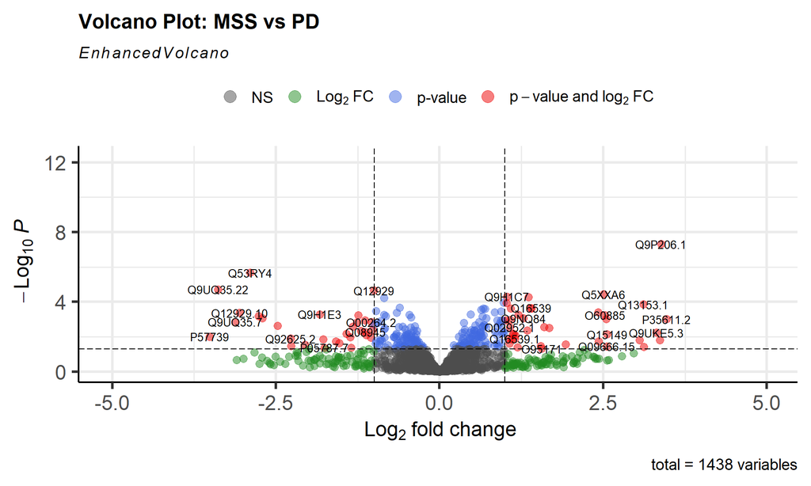

**Interpretación de los resultados**:

1. **Fosfopéptidos Significativos**: Los puntos en rojo, situados en los extremos del gráfico, representan fosfopéptidos con diferencias significativas tanto en log2 fold change como en p-valor. Fosfopéptidos como Q9P206.1 (con un log2 fold change positivo) sugieren una mayor abundancia en PD, mientras que otros, como Q9UQ35.22, tienen mayor abundancia en MSS.
2. **Eficacia de la Normalización**: La Quantile Normalization ha mejorado la consistencia entre muestras, resaltando los fosfopéptidos con diferencias biológicamente relevantes entre MSS y PD, lo cual facilita la identificación de posibles biomarcadores tumorales para diferenciar estos subtipos.

**5.1.6 Integramos los datos en el contenedor `SummarizedExperiment`**

Reorganizamos los resultados dentro de SummarizedExperiment para tener todos los datos en un solo contenedor, facilitando el acceso y la gestión de datos a lo largo del proceso.

##### **5.2 ¿Cómo se controló la tasa de descubrimiento falso (FDR) en el análisis?**

La tasa de descubrimiento falso (FDR) se controló aplicando el método de **Benjamini-Hochberg** durante el análisis con `limma`. Este ajuste se realizó al extraer los resultados mediante `topTable` con el parámetro `adjust = "BH"`.

El método reordena los p-valores y ajusta los umbrales de significancia, reduciendo la probabilidad de falsos positivos en las múltiples pruebas realizadas. Para validar la confiabilidad de los fosfopéptidos seleccionados, se generaron **Volcano Plots**, que permitieron verificar visualmente la relación entre log Fold Change y significancia estadística.

##### **5.3 ¿Cómo se interpretan los valores de log Fold Change y qué nivel de cambio de abundancia se considera biológicamente relevante?**

El **log Fold Change (logFC)** mide el cambio en la abundancia de un fosfopéptido entre los grupos PD y MSS, expresado en escala logarítmica base 2:

- **logFC positivo:** Mayor abundancia en PD.
- **logFC negativo:** Mayor abundancia en MSS.

Un **logFC ≥ |1|** se consideró biológicamente relevante, ya que indica un cambio de al menos el doble o la mitad en la abundancia. Este umbral es ampliamente aceptado en estudios de proteómica, ya que garantiza que las diferencias detectadas tengan implicaciones funcionales o biológicas significativas. Además, este criterio fue validado mediante PCA, que mostró que los fosfopéptidos seleccionados contribuían a la separación biológica observada entre MSS y PD.

##### **5.4 ¿Qué herramientas estadísticas o métodos se utilizaron para garantizar la robustez de los resultados?**

Para garantizar la robustez de los resultados, se implementaron las siguientes herramientas y métodos:

1. **Quantile Normalization:** Reduciendo la variabilidad técnica entre muestras, se aseguraron distribuciones homogéneas de abundancia, mejorando la comparabilidad entre MSS y PD.
2. **`limma` con `arrayWeights`:** Este ajuste asignó pesos adaptativos a las muestras con mayor variabilidad residual, reduciendo la influencia de outliers como la muestra M43 en PD.
3. **`duplicateCorrelation`:** Modeló la correlación entre réplicas técnicas, asegurando que la variabilidad entre ellas no comprometiera los resultados.
4. **Ajuste Bayesiano (`eBayes`):** Estabilizó los errores estándar estimados, aumentando la precisión en la identificación de diferencias significativas.
5. **Control de FDR con Benjamini-Hochberg:** Ajustó los p-valores para minimizar falsos positivos.
6. **Validación visual:** Se utilizaron **Volcano Plots** y análisis **PCA** para verificar que las diferencias detectadas reflejaban variaciones biológicas reales y no artefactos técnicos.

En conjunto, estas herramientas aseguraron resultados confiables y estadísticamente robustos, proporcionando una base sólida para la identificación de fosfopéptidos diferencialmente abundantes y su interpretación biológica.

#### **6: Análisis de Significación Biológica con Enriquecimiento Funcional**

**Objetivo:**

El objetivo de este apartado es identificar procesos biológicos, funciones moleculares y vías de señalización asociadas a los fosfopéptidos diferencialmente abundantes en los subtipos tumorales MSS y PD, con el fin de comprender las funciones específicas y mecanismos que podrían diferenciar cada subtipo tumoral.

En otras palabras, se pretende identificar y caracterizar biológicamente fosfopéptidos diferencialmente abundantes en los subtipos tumorales MSS y PD, explorando su potencial como biomarcadores y su participación en procesos y vías clave en el cáncer.

**Cuestiones clave:**

Para conseguir dicho objetivo planteamos una serie de cuestiones que caracterizaran el proceso de análisis a seguir:

##### **6.1 ¿Qué procesos biológicos, funciones moleculares y vías de señalización están enriquecidos en los grupos de fosfopéptidos diferencialmente abundantes de MSS y PD?**

Para llevar a cabo este análisis, se utilizó **ClusterProfiler** junto con bases de datos como **GO (Gene Ontology)**, **KEGG**, y **Reactome**, permitiendo mapear los fosfopéptidos a procesos biológicos, funciones moleculares y rutas metabólicas específicas. Además, herramientas como **ReactomePA**, **UniProt**, y **BioMart** facilitaron la anotación y contextualización de los fosfopéptidos, proporcionando una interpretación funcional detallada. Los resultados se visualizaron mediante **Dot Plots**, **Enrichment Maps**, y **Network Plots**, que destacaron las diferencias funcionales más significativas entre MSS y PD.

##### **6.2 ¿Qué funciones moleculares específicas están asociadas a los fosfopéptidos diferencialmente abundantes en MSS o PD, y cómo se relacionan con la progresión tumoral?**

**Métodos empleados:**

1. **ReactomePA y GO (Gene Ontology):** Utilizados para mapear las funciones moleculares específicas de los fosfopéptidos.
2. **UniProt y BioMart:** Proporcionaron descripciones funcionales detalladas de las proteínas asociadas a los fosfopéptidos.
3. **Visualizaciones:** Los Dot Plots y Enrichment Maps facilitaron la interpretación visual de las funciones moleculares enriquecidas en cada subtipo.

#### **6.3 ¿Qué herramientas o bases de datos se utilizaron para asignar significado funcional y contextual a los fosfopéptidos diferencialmente abundantes?**

Se emplearon diversas herramientas y bases de datos para asignar contexto funcional y biológico a los fosfopéptidos diferencialmente abundantes entre MSS y PD. Entre las principales destacan:

1. **ClusterProfiler y ReactomePA**: Estas herramientas permitieron realizar análisis de enriquecimiento funcional, identificando procesos biológicos, funciones moleculares y rutas de señalización enriquecidas.
2. **GO (Gene Ontology), KEGG y Reactome**: Bases de datos utilizadas para mapear los fosfopéptidos a términos biológicos específicos y rutas metabólicas relevantes, como MAPK/ERK y PI3K/AKT.
3. **UniProt y BioMart**: Ayudaron a anotar los genes asociados con los fosfopéptidos, proporcionando detalles sobre su funcionalidad y localización subcelular.
4. **PubMed y Human Protein Atlas**: Se utilizaron para validar la relevancia clínica de los fosfopéptidos seleccionados, verificando su expresión en tejidos tumorales y su conexión con otros estudios de cáncer.
5. **STRINGdb**: Facilitó el análisis de interacción proteína-proteína (PPI), identificando redes moleculares clave asociadas a los fosfopéptidos y destacando proteínas centrales involucradas en procesos críticos.

**Cómo se abordó:** Los resultados de los análisis de enriquecimiento funcional y las anotaciones de proteínas se representaron gráficamente mediante **Dot Plots**, **Enrichment Maps**, y **Network Plots**, que facilitaron la interpretación visual de los términos y redes funcionales más relevantes.

##### **6.4 ¿Podrían estos fosfopéptidos diferencialmente abundantes servir como biomarcadores o proporcionar información sobre los mecanismos implicados en la progresión del cáncer?**

Además, se realizó un análisis de **interacción proteína-proteína (PPI)** utilizando herramientas como **STRINGdb**, que permitió identificar redes moleculares clave asociadas a los fosfopéptidos diferencialmente abundantes. Estas redes destacaron proteínas centrales (hub proteins) involucradas en procesos tumorales críticos, proporcionando un marco adicional para explorar la funcionalidad biológica de los fosfopéptidos seleccionados.

Para reforzar la validez clínica de los resultados, se exploraron bases de datos como **Human Protein Atlas** y literatura en **PubMed**, confirmando la expresión de varias de las proteínas relacionadas con los fosfopéptidos en tipos de cáncer específicos. Estas validaciones respaldan la relevancia biológica y clínica de los biomarcadores identificados, posicionándolos como candidatos prometedores para aplicaciones diagnósticas y terapéuticas.

##### **6.5 ¿Cuáles son las limitaciones del análisis de enriquecimiento funcional para interpretar diferencias en la fosforilación en el contexto del cáncer, y cómo pueden influir en la interpretación de los resultados?**

El análisis de enriquecimiento funcional es una herramienta valiosa para interpretar datos de fosforilación en el contexto del cáncer; sin embargo, presenta varias limitaciones que pueden influir en la interpretación de los resultados:

1. **Dependencia de bases de datos y anotaciones incompletas**: Las herramientas como GO, KEGG y Reactome dependen de la calidad y actualización de sus bases de datos. La falta de anotaciones completas o específicas para ciertos fosfopéptidos puede llevar a omitir rutas relevantes o a sesgos hacia procesos y vías mejor estudiados.
2. **Asignación estática de términos biológicos**: Los métodos de enriquecimiento funcional suelen asignar términos biológicos de manera estática, sin considerar la dinámica del microambiente tumoral ni las interacciones complejas entre proteínas en un sistema vivo. Esto limita la capacidad para interpretar adecuadamente el impacto biológico de los fosfopéptidos diferencialmente abundantes.
3. **Sesgo técnico en la detección de fosfopéptidos**: Los métodos de enriquecimiento de fosfopéptidos, como TiO₂ y α-pTyr, pueden favorecer la detección de fosfopéptidos más abundantes o aquellos asociados a sitios de fosforilación mejor caracterizados. Esto restringe la cobertura global de las modificaciones de fosforilación y podría excluir fosfopéptidos relevantes en subtipos menos estudiados.
4. **Validación experimental limitada**: Aunque los análisis in silico identifican rutas y procesos potencialmente relevantes, es esencial complementar estos hallazgos con estudios funcionales adicionales para confirmar su impacto en la progresión del cáncer y su potencial utilidad clínica.
5. **Tamaño de muestra reducido**: El reducido tamaño muestral de la mayoría de los experimentos y su acotación a un escenario específico suponen factores limitantes en la evaluación de este tipo de estudios.
6. **Selección de puntos de corte arbitrarios**: La elección de un punto de corte a partir del cual se selecciona un grupo de genes con diferencia de expresión puede introducir sesgos en el análisis de enriquecimiento funcional.

Estas limitaciones subrayan la importancia de interpretar los resultados con precaución, considerando los posibles sesgos y la necesidad de validación experimental para garantizar que las conclusiones reflejen la biología real del sistema tumoral.

**Estrategia:**

Para responder a las cuestiones planteadas, diseñamos una estrategia de análisis funcional basada en metodologías ampliamente usadas en estudios de fosfoproteómica y biomarcadores. Nuestro objetivo es identificar procesos biológicos, funciones moleculares y rutas de señalización asociadas a los fosfopéptidos diferencialmente abundantes en los subtipos tumorales MSS y PD, y explorar su potencial como biomarcadores.

1. **Preparación de listas de fosfopéptidos**:
   - Comenzamos filtrando los fosfopéptidos diferencialmente abundantes en función del log Fold Change y el p-valor ajustado, obtenidos de los resultados del análisis estadístico. Esto nos permite generar dos listas: una para fosfopéptidos más abundantes en el grupo PD y otra en el grupo MSS.
   - **Herramientas**: Usamos los resultados procesados en `limma` y almacenamos estas listas en el contenedor `SummarizedExperiment` para asegurar la integridad de los datos y facilitar su manipulación posterior.
2. **Anotación funcional y mapeo de fosfopéptidos**:
   - *Objetivo*: Antes del análisis de enriquecimiento, buscamos comprender las funciones de cada fosfopéptido. Utilizamos anotaciones detalladas para contextualizar su papel biológico.
   - A través de **UniProt**, obtenemos nombres de genes, nombres de proteínas y descripciones funcionales, lo que proporciona un contexto inicial.
   - Complementamos esta información con **BioMart (Ensembl)**, añadiendo datos sobre localización subcelular, funciones moleculares y procesos biológicos asociados a las proteínas identificadas.
3. **Análisis de enriquecimiento funcional en bases de datos**:
   - Exploramos términos enriquecidos en bases de datos clave para identificar procesos biológicos, funciones moleculares y rutas de señalización en cada grupo de fosfopéptidos.
   - **Gene Ontology (GO)**: Analizamos los términos de **Procesos Biológicos (BP)**, **Funciones Moleculares (MF)** y **Componentes Celulares (CC)** para obtener una visión detallada de los roles funcionales.
   - **KEGG**: Exploramos rutas de señalización, especialmente aquellas vinculadas con el cáncer y otros procesos relevantes.
   - **Reactome**: Investigamos rutas detalladas de señalización en el contexto de cáncer y fosforilación.
   - **Herramientas**: Utilizamos `ClusterProfiler`, `ReactomePA`, y consideramos **DAVID** o **Metascape** como alternativas para integrar varias bases de datos en el análisis de enriquecimiento.
4. **Análisis de redes de interacción**:
   - *Objetivo*: Visualizar y comprender las **interacciones funcionales directas** entre los fosfopéptidos identificados, explorando redes de señalización que podrían estar activas en cada subtipo tumoral. Este análisis profundiza en la **organización estructural y funcional** de los fosfopéptidos, más allá de la identificación de procesos y rutas enriquecidas.
   - A diferencia del análisis de enriquecimiento (punto 3), que proporciona una visión general sobre **qué funciones y procesos** están asociados con los fosfopéptidos en cada grupo, este análisis se centra en **cómo** los fosfopéptidos **interactúan entre sí**. Aquí identificamos redes de interacción proteína-proteína (PPI) que revelan posibles **complejos funcionales** o **módulos** dentro de la red, proporcionando una perspectiva detallada sobre la **arquitectura de señalización y regulación** entre fosfopéptidos en los subtipos PD y MSS.
   - **Metodología**: Utilizamos `STRINGdb` para identificar redes de interacción PPI relevantes, y visualizamos estas redes con `igraph` y `ggraph`. También empleamos métodos de detección de comunidades para identificar grupos o módulos altamente conectados, que pueden representar complejos funcionales o estructuras de señalización.
   - **Interpretación**: Los módulos o comunidades dentro de la red pueden estar relacionados con funciones o rutas específicas, y para interpretarlos realizamos un análisis de enriquecimiento funcional de estos subgrupos específicos. Esto permite observar patrones de interacción que podrían indicar redes de señalización activas, así como **potenciales puntos de intervención** o **biomarcadores**, en función de la conectividad de cada fosfopéptido dentro de la red.
5. **Validación de biomarcadores en bases de datos clínicas**:
   - *Objetivo*: Confirmar el potencial de los fosfopéptidos como biomarcadores que diferencien entre MSS y PD.
   - Utilizamos **Human Protein Atlas** para investigar los patrones de expresión de las proteínas en tejidos humanos y en el contexto de diferentes tipos de cáncer.
   - Realizamos búsquedas en **PubMed** para validar la relevancia de estos fosfopéptidos en estudios relacionados, evaluando su implicación en procesos similares.
6. **Interpretación de resultados**:
   - Con los datos obtenidos, comparamos los términos y rutas enriquecidas entre los grupos MSS y PD. Evaluamos las funciones y mecanismos moleculares predominantes en cada grupo y exploramos cómo estos pueden reflejar la progresión tumoral y las características biológicas de cada subtipo.

##### **Paso 1: Preparación de las Listas de Fosfopéptidos Diferencialmente Abundantes**

Para realizar el análisis de enriquecimiento, primero necesitamos obtener listas de fosfopéptidos que muestran una abundancia diferencial significativa entre los subtipos tumorales. Estas listas se generarán a partir de los resultados estadísticos obtenidos en el análisis con **limma** y **arrayWeights**.

1. **Filtramos los Fosfopéptidos con Significancia Estadística**
   - Seleccionamos aquellos fosfopéptidos que presenten un **p-valor ajustado menor a 0.05** para asegurar que los cambios observados son estadísticamente significativos.
2. **Aplicamos el Umbral de Fold Change**
   - Para destacar fosfopéptidos con cambios relevantes en abundancia, seleccionamos los que tengan un **log Fold Change (logFC) mayor a 1 o menor a -1**. Esto asegura que los fosfopéptidos seleccionados tengan al menos un cambio de dos veces en la abundancia entre los grupos.
3. **Dividimos en Grupos**
   - Generamos dos listas separadas y almacenamos los resultados en el contenedor `SummarizedExperiment`:
     - **Fosfopéptidos más abundantes en PD**: logFC > 1.
     - **Fosfopéptidos más abundantes en MSS**: logFC < -1.

```
##             logFC  AveExpr         t      P.Value    adj.P.Val        B
## Q9P206.1 3.386791 2.419242 12.772564 4.766759e-08 6.854599e-05 8.539915
## Q5XXA6   2.508416 3.782184  6.568731 3.602977e-05 1.036216e-02 2.658059
## Q9H1C7   1.026968 5.337423  6.344868 4.929600e-05 1.064291e-02 2.357119
## P07355   1.357485 4.651341  6.309805 5.180834e-05 1.064291e-02 2.309288
## Q02952   1.022853 4.890719  5.754309 1.164498e-04 1.674549e-02 1.526047
## Q13153.1 3.117323 2.468207  5.635737 1.391965e-04 1.819678e-02 1.352615
```

```
##               logFC  AveExpr         t      P.Value   adj.P.Val           B
## Q53RY4    -2.894041 2.189480 -8.834600 2.124214e-06 0.001527310  5.30270336
## Q9UQ35.22 -3.386333 2.369327 -7.023290 1.945022e-05 0.008040986  3.24590008
## Q12929    -1.000647 4.160975 -6.918536 2.236714e-05 0.008040986  3.11314834
## Q12929.10 -3.053860 2.874827 -4.919399 4.267038e-04 0.025566671  0.25838996
## Q9H1E3    -1.829939 3.440968 -4.795684 5.215871e-04 0.026654645  0.06154028
## P29692.2  -1.239947 5.746908 -4.736490 5.746134e-04 0.026654645 -0.03343277
```

```
## List of 2
##  $ pd_peptides :'data.frame':    17 obs. of  6 variables:
##   ..$ logFC    : num [1:17] 3.39 2.51 1.03 1.36 1.02 ...
##   ..$ AveExpr  : num [1:17] 2.42 3.78 5.34 4.65 4.89 ...
##   ..$ t        : num [1:17] 12.77 6.57 6.34 6.31 5.75 ...
##   ..$ P.Value  : num [1:17] 4.77e-08 3.60e-05 4.93e-05 5.18e-05 1.16e-04 ...
##   ..$ adj.P.Val: num [1:17] 6.85e-05 1.04e-02 1.06e-02 1.06e-02 1.67e-02 ...
##   ..$ B        : num [1:17] 8.54 2.66 2.36 2.31 1.53 ...
##  $ mss_peptides:'data.frame':    12 obs. of  6 variables:
##   ..$ logFC    : num [1:12] -2.89 -3.39 -1 -3.05 -1.83 ...
##   ..$ AveExpr  : num [1:12] 2.19 2.37 4.16 2.87 3.44 ...
##   ..$ t        : num [1:12] -8.83 -7.02 -6.92 -4.92 -4.8 ...
##   ..$ P.Value  : num [1:12] 2.12e-06 1.95e-05 2.24e-05 4.27e-04 5.22e-04 ...
##   ..$ adj.P.Val: num [1:12] 0.00153 0.00804 0.00804 0.02557 0.02665 ...
##   ..$ B        : num [1:12] 5.3027 3.2459 3.1131 0.2584 0.0615 ...
```

**Interpretación de los resultados**

- **pd_peptides**: Lista de fosfopéptidos con mayor abundancia en el grupo PD, que usaremos para identificar procesos y rutas enriquecidas en este grupo.
- **mss_peptides**: Lista de fosfopéptidos con mayor abundancia en el grupo MSS, para analizar funciones y rutas específicas en MSS.

##### **Paso 2: Análisis Funcional y Mapeo de Fosfopéptidos**

En este paso, asignaremos información funcional a los fosfopéptidos seleccionados para obtener una descripción detallada de cada uno antes de llevar a cabo el análisis de enriquecimiento. Esto incluye obtener los nombres de genes, descripciones funcionales, y otra información relevante asociada a cada fosfopéptido.

La anotación funcional permite contextualizar los fosfopéptidos dentro de procesos biológicos conocidos y facilita la interpretación biológica en los análisis de enriquecimiento posteriores.

Para llevar a cabo esta anotación, utilizaremos dos herramientas principales:

1. **UniProt**: Proporciona una base de datos exhaustiva sobre proteínas, incluyendo nombres de genes, descripciones funcionales y asociaciones con procesos biológicos y funciones moleculares.
2. **BioMart (Ensembl)**: Permite obtener información sobre la localización subcelular, funciones moleculares y procesos biológicos. BioMart también es muy útil para transformar identificadores de proteínas a otros formatos si es necesario.

**Pasos a Seguir**

1. Convertir los IDs de los fosfopéptidos a nombres de genes y obtener descripciones funcionales.
2. Obtener información sobre procesos biológicos, funciones moleculares, y localización subcelular.

##### **Paso 2.1: Anotación con UniProt**

Para realizar una conexión confiable con UniProt y extraer anotaciones específicas, podemos usar un método basado en la API REST de UniProt. La ventaja de este enfoque es que permite una consulta directa a UniProt sin depender de paquetes como `UniProt.ws`, que pueden tener limitaciones o problemas de compatibilidad. Utilizaremos `httr` y `jsonlite`, dos paquetes en R que permiten hacer solicitudes a la API y procesar las respuestas de manera eficiente.

Dado que tenemos listas de péptidos diferenciados en PD y MSS, el código se ajustará para aceptar `UniProt IDs` y devolver una lista con las anotaciones de interés.

```
## $results
##   accession database entryVersion firstRelease firstReleaseDate lastRelease lastReleaseDate   name
## 1    Q9P206   TrEMBL            1           15      01-Oct-2000          15     01-Oct-2000 Q9P206
##   sequenceVersion
## 1               1
```

[output not shown]

[output cut: 260 more lines]

[output not shown]

**Interpretación de los resultados**

**PD:**

- Las proteínas de PD presentan características que favorecen una alta adaptabilidad y proliferación, con dominios que facilitan la activación rápida en respuesta a condiciones de estrés.
- Predomina la presencia de múltiples isoformas, lo que les permite una mayor flexibilidad funcional y capacidad de respuesta a estímulos variados, favoreciendo la proliferación y la agresividad tumoral.
- Las proteínas de PD están asociadas a rutas de proliferación celular, señalización de estrés y reparación celular, con conexiones en bases de datos como KEGG y Reactome en contextos de cáncer.
- Las modificaciones postraduccionales, especialmente la fosforilación, activan continuamente rutas proliferativas, contribuyendo a un perfil tumoral agresivo y adaptable.

**MSS:**

- Las proteínas de MSS muestran dominios transmembrana y características estructurales que facilitan la señalización en la membrana, indicando un rol más estable en la comunicación celular con el entorno.
- La menor variabilidad de isoformas en MSS sugiere una función más estable y específica, enfocada en la homeostasis y sin énfasis en adaptaciones rápidas.
- Las proteínas de MSS están vinculadas a rutas de señalización celular y diferenciación, que reflejan un perfil funcional menos proliferativo y más orientado a la estabilidad.
- La fosforilación en proteínas de MSS se asocia con la regulación de funciones estables y la preservación de la estructura celular, contribuyendo a un perfil tumoral menos agresivo y más homeostático.

##### **Paso 2.2: Anotación Adicional con BioMart**

```
##   uniprotswissprot hgnc_symbol
## 1           O60885        BRD4
## 2           O75494      SRSF10
## 3           P07355       ANXA2
## 4           Q02952      AKAP12
## 5           Q16539      MAPK14
## 6           Q5XXA6        ANO1
## 7           Q86SQ4      ADGRG6
## 8           Q9H1C7      CYSTM1
## 9           Q9NQ84      GPRC5C
##                                                                               description
## 1                            bromodomain containing 4 [Source:HGNC Symbol;Acc:HGNC:13575]
## 2         serine and arginine rich splicing factor 10 [Source:HGNC Symbol;Acc:HGNC:16713]
## 3                                            annexin A2 [Source:HGNC Symbol;Acc:HGNC:537]
## 4                         A-kinase anchoring protein 12 [Source:HGNC Symbol;Acc:HGNC:370]
## 5                  mitogen-activated protein kinase 14 [Source:HGNC Symbol;Acc:HGNC:6876]
## 6                                         anoctamin 1 [Source:HGNC Symbol;Acc:HGNC:21625]
## 7              adhesion G protein-coupled receptor G6 [Source:HGNC Symbol;Acc:HGNC:13841]
## 8     cysteine rich transmembrane module containing 1 [Source:HGNC Symbol;Acc:HGNC:30239]
## 9 G protein-coupled receptor class C group 5 member C [Source:HGNC Symbol;Acc:HGNC:13309]
```

```
##   uniprotswissprot hgnc_symbol
## 1           Q12929        EPS8
## 2           Q53RY4     KRTCAP3
## 3           Q9H1E3      NUCKS1
## 4           Q9UD71     PPP1R1B
##                                                                                         description
## 1                    EGFR pathway substrate 8, signaling adaptor [Source:HGNC Symbol;Acc:HGNC:3420]
## 2                             keratinocyte associated protein 3 [Source:HGNC Symbol;Acc:HGNC:28943]
## 3 nuclear casein kinase and cyclin dependent kinase substrate 1 [Source:HGNC Symbol;Acc:HGNC:29923]
## 4          protein phosphatase 1 regulatory inhibitor subunit 1B [Source:HGNC Symbol;Acc:HGNC:9287]
```

**Interpretación de los resultados**

Los resultados obtenidos en BioMart ofrecen anotaciones esenciales para los fosfopéptidos diferencialmente abundantes en los subtipos PD y MSS, proporcionando información clave sobre el rol de estas proteínas en procesos biológicos específicos.

1. **Grupo PD**:
   - Las proteínas diferencialmente abundantes en PD, como **BRD4** (un regulador de la transcripción) y **MAPK14** (una proteína quinasa implicada en la respuesta al estrés), están relacionadas con la regulación de la transcripción y la activación de rutas de supervivencia y proliferación celular. Estas proteínas están típicamente vinculadas a respuestas celulares que promueven la adaptación a entornos agresivos o desfavorables.
   - La abundancia de fosfopéptidos que regulan rutas de señalización de supervivencia y proliferación en PD sugiere un perfil tumoral más agresivo, con mecanismos que favorecen el crecimiento celular descontrolado y la resistencia a factores de estrés. Esta predominancia en vías de señalización asociadas a la activación y proliferación celular puede reflejar un comportamiento biológico que facilita la progresión tumoral y la evasión de respuestas apoptóticas.
2. **Grupo MSS**:
   - En contraste, las proteínas diferencialmente abundantes en MSS, como **EPS8** (involucrada en la transducción de señales en la membrana celular) y **NUCKS1** (asociada a la regulación de la transcripción y funciones de respuesta al daño del ADN), están relacionadas con la señalización en la membrana y la homeostasis celular.
   - En MSS, la fosforilación parece estar modulando funciones que mantienen la estabilidad celular y responden a señales externas sin inducir necesariamente proliferación agresiva. Esto sugiere un perfil menos proliferativo y más orientado a la homeostasis y la diferenciación, indicando que MSS podría representar un subtipo tumoral menos agresivo y con una mayor estabilidad en comparación con PD.

Estos hallazgos resaltan diferencias clave en los mecanismos de señalización entre PD y MSS. En PD, la fosforilación potencia vías que favorecen la proliferación celular y la adaptación a entornos de alto estrés, características típicas de tumores más agresivos. Por otro lado, en MSS, los fosfopéptidos están más orientados a la regulación de señales de membrana y funciones de estabilidad celular, reflejando una biología menos agresiva y más orientada a la homeostasis.

##### **Paso 3: Análisis de Enriquecimiento Funcional en Bases de Datos**

Para entender el papel biológico y funcional de los fosfopéptidos diferencialmente abundantes en los subtipos tumorales PD y MSS, realizamos un análisis de enriquecimiento funcional en distintas bases de datos. Para ello, utilizaremos los UniProt IDs de los fosfopéptidos diferencialmente abundantes en PD y MSS, almacenados en el objeto SummarizedExperiment (se).

1. **Análisis de Enriquecimiento Funcional con ClusterProfiler**
   - Utilizamos `ClusterProfiler` para realizar un análisis de enriquecimiento en **Gene Ontology (GO)** y **KEGG**.
   - Realizamos análisis específicos para cada aspecto de GO: **Procesos Biológicos (BP)**, **Funciones Moleculares (MF)**, y **Componentes Celulares (CC)**, y analizamos rutas de señalización en KEGG.
2. **Análisis de Rutas con ReactomePA**
   - Usamos `ReactomePA` para analizar rutas detalladas en el contexto de señalización y cáncer, con un enfoque en fosforilación.

**Visualización de los Resultados de Enriquecimiento**

Para interpretar eficazmente los resultados del análisis de enriquecimiento, utilizamos tres tipos de gráficos: el **Dot Plot**, el **Enrichment Map**, y el **Network Plot**.

- **Dot Plot**: muestra los términos enriquecidos en función de la proporción de genes (GeneRatio) y el valor ajustado de p (p.adjust). La intensidad del color refleja la significancia estadística, mientras que el tamaño de los puntos indica la cantidad de genes implicados. En nuestro análisis, los Dot Plots para PD y MSS permitirán identificar rápidamente los términos más representativos y su nivel de enriquecimiento en cada subtipo tumoral.
- **Enrichment Map**: permite visualizar relaciones y agrupaciones entre términos enriquecidos. Los términos se conectan si están relacionados semánticamente, formando clusters que indican temas funcionales comunes. En el contexto de PD y MSS, este gráfico facilita la identificación de grupos funcionales específicos en los fosfopéptidos diferencialmente abundantes de cada subtipo, lo que ayuda a comprender los mecanismos biológicos que predominan en cada uno.
- **Network Plot**: resalta la interacción entre los términos enriquecidos y los genes individuales. Cada término se conecta con los genes que lo componen, proporcionando una visión detallada de cómo los fosfopéptidos se relacionan con rutas o procesos específicos. En este caso, esperamos ver cómo diferentes rutas (o términos de GO) se relacionan con los genes de PD y MSS, ilustrando su papel en el perfil funcional de cada subtipo.

##### **Paso 3.1.1: Enriquecimiento en GO (Gene Ontology)**

Para explorar las funciones biológicas y moleculares de los fosfopéptidos diferencialmente abundantes en MSS y PD, realizamos un análisis de enriquecimiento en términos de GO utilizando la herramienta `clusterProfiler`. Este análisis se enfoca en tres categorías clave de la Ontología de Genes:

- **Biological Process (BP)**: Procesos biológicos generales, como proliferación o apoptosis, que pueden diferenciar estos subtipos.
- **Molecular Function (MF)**: Funciones moleculares específicas, como actividad enzimática, que reflejan la acción directa de los fosfopéptidos.
- **Cellular Component (CC)**: Localización subcelular, proporcionando contexto sobre dónde ocurren estos eventos de fosforilación.

```
##            ONTOLOGY         ID
## GO:1905597       BP GO:1905597
## GO:1900141       BP GO:1900141
## GO:0032804       BP GO:0032804
## GO:0061868       BP GO:0061868
## GO:0061869       BP GO:0061869
## GO:0061870       BP GO:0061870
##                                                                                   Description
## GO:1905597           positive regulation of low-density lipoprotein particle receptor binding
## GO:1900141                                    regulation of oligodendrocyte apoptotic process
## GO:0032804 negative regulation of low-density lipoprotein particle receptor catabolic process
## GO:0061868                                                    hepatic stellate cell migration
## GO:0061869                                      regulation of hepatic stellate cell migration
## GO:0061870                             positive regulation of hepatic stellate cell migration
##            GeneRatio   BgRatio RichFactor FoldEnrichment   zScore       pvalue   p.adjust qvalue
## GO:1905597       1/9 11/107869 0.09090909      1089.5859 32.98149 0.0009174396 0.03367039     NA
## GO:1900141       1/9 15/107869 0.06666667       799.0296 28.23475 0.0012508685 0.03367039     NA
## GO:0032804       1/9 16/107869 0.06250000       749.0903 27.33602 0.0013342103 0.03367039     NA
## GO:0061868       1/9 17/107869 0.05882353       705.0261 26.51774 0.0014175458 0.03367039     NA
## GO:0061869       1/9 17/107869 0.05882353       705.0261 26.51774 0.0014175458 0.03367039     NA
## GO:0061870       1/9 17/107869 0.05882353       705.0261 26.51774 0.0014175458 0.03367039     NA
##            geneID Count
## GO:1905597 P07355     1
## GO:1900141 Q02952     1
## GO:0032804 P07355     1
## GO:0061868 Q02952     1
## GO:0061869 Q02952     1
## GO:0061870 Q02952     1
```

```
##            ONTOLOGY         ID                                       Description GeneRatio
## GO:0044868       BP GO:0044868    modulation by host of viral molecular function       1/3
## GO:0052422       BP GO:0052422 modulation by host of symbiont catalytic activity       1/3
## GO:0043921       BP GO:0043921         modulation by host of viral transcription       1/3
## GO:0035822       BP GO:0035822                                   gene conversion       1/3
## GO:0007621       BP GO:0007621         negative regulation of female receptivity       1/3
## GO:0045924       BP GO:0045924                  regulation of female receptivity       1/3
##              BgRatio RichFactor FoldEnrichment   zScore       pvalue    p.adjust qvalue geneID
## GO:0044868 10/107869 0.10000000      3595.6333 59.95026 0.0002780919 0.007585504     NA Q9H1E3
## GO:0052422 13/107869 0.07692308      2765.8718 52.57620 0.0003615094 0.007585504     NA Q9H1E3
## GO:0043921 15/107869 0.06666667      2397.0889 48.94351 0.0004171185 0.007585504     NA Q9H1E3
## GO:0035822 21/107869 0.04761905      1712.2063 41.35906 0.0005839335 0.007585504     NA Q9H1E3
## GO:0007621 22/107869 0.04545455      1634.3788 40.40721 0.0006117342 0.007585504     NA Q9UD71
## GO:0045924 43/107869 0.02325581       836.1938 28.88846 0.0011954294 0.008871821     NA Q9UD71
##            Count
## GO:0044868     1
## GO:0052422     1
## GO:0043921     1
## GO:0035822     1
## GO:0007621     1
## GO:0045924     1
```

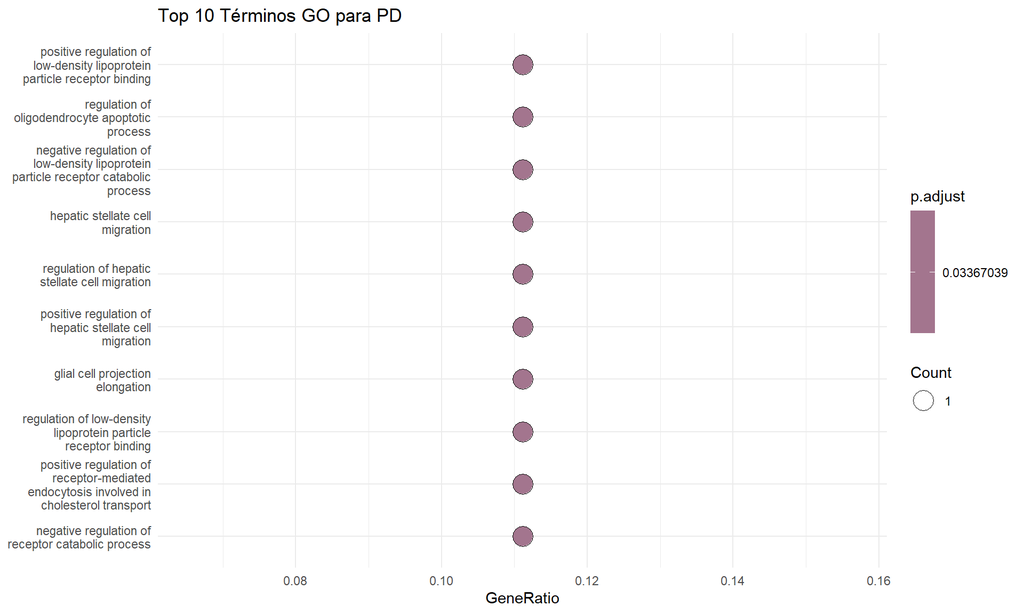

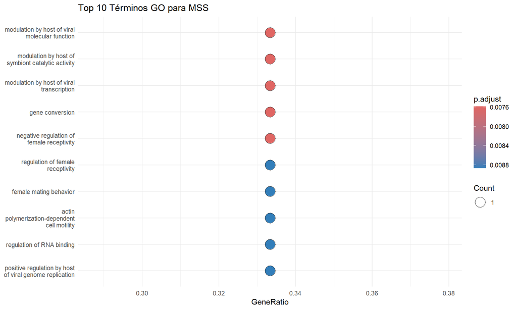

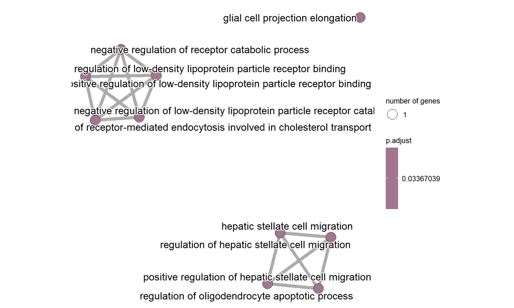

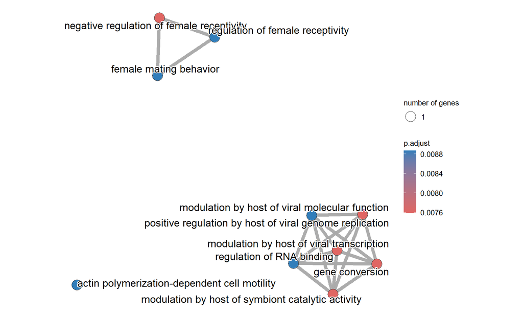

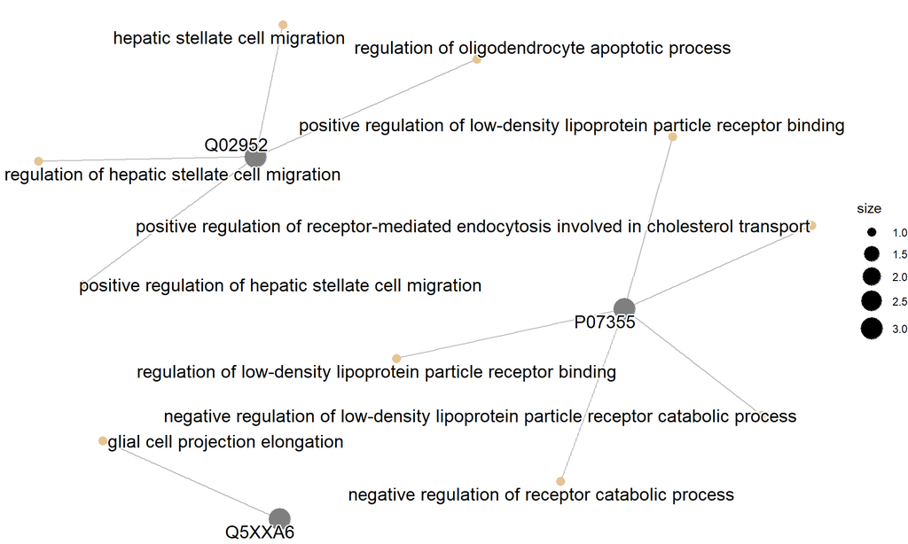

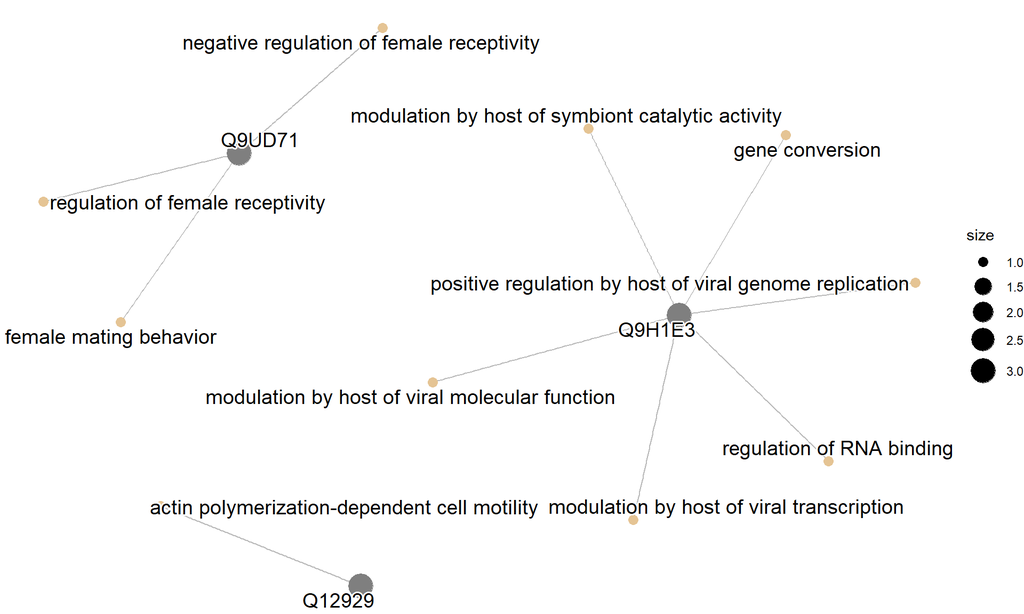

**Interpretación de los resultados**

**Conclusión**

Las proteínas y fosfopéptidos más abundantes en PD están orientados a facilitar la **proliferación celular, la migración y la respuesta activa a señales externas**. Esto respalda un perfil tumoral más agresivo, con capacidad de adaptación y diseminación. Mientras que los fosfopéptidos en MSS se orientan a un perfil **homeostático y de señalización estable**, con menor foco en la proliferación agresiva y mayor inclinación hacia la regulación intracelular y la estabilidad.

Estas diferencias resaltan cómo los fosfopéptidos en PD y MSS se asocian a rutas funcionales y biológicas distintas, reflejando diferencias en los mecanismos subyacentes de estos subtipos tumorales.

##### **Paso 3.1.2: Análisis de Enriquecimiento en Rutas de Señalización (KEGG - Kyoto Encyclopedia of Genes and Genomes)**

Para identificar rutas de señalización críticas, especialmente relacionadas con el cáncer y el crecimiento celular, utilizamos la base de datos KEGG. KEGG permite el análisis de rutas específicas, como aquellas vinculadas a la fosforilación y activación de proteínas, brindando una perspectiva sobre cómo se modulan estas vías en los subtipos MSS y PD. Este análisis es fundamental para identificar rutas que puedan estar alteradas en el contexto tumoral.

```
##                                      category                   subcategory       ID
## hsa05132                       Human Diseases Infectious disease: bacterial hsa05132
## hsa04370 Environmental Information Processing           Signal transduction hsa04370
## hsa04622                   Organismal Systems                 Immune system hsa04622
## hsa05120                       Human Diseases Infectious disease: bacterial hsa05120
## hsa04664                   Organismal Systems                 Immune system hsa04664
## hsa05133                       Human Diseases Infectious disease: bacterial hsa05133
##                                                         Description GeneRatio   BgRatio  RichFactor
## hsa05132                                       Salmonella infection       2/3 340/11065 0.005882353
## hsa04370                                     VEGF signaling pathway       1/3  90/11065 0.011111111
## hsa04622                      RIG-I-like receptor signaling pathway       1/3  97/11065 0.010309278
## hsa05120 Epithelial cell signaling in Helicobacter pylori infection       1/3  97/11065 0.010309278
## hsa04664                            Fc epsilon RI signaling pathway       1/3 104/11065 0.009615385
## hsa05133                                                  Pertussis       1/3 111/11065 0.009009009
##          FoldEnrichment   zScore      pvalue   p.adjust   qvalue        geneID Count
## hsa05132       21.69608 6.383057 0.002766936 0.08670417 0.051522 P07355/Q16539     2
## hsa04370       40.98148 6.271591 0.024205499 0.08670417 0.051522        Q16539     1
## hsa04622       38.02405 6.031232 0.026071602 0.08670417 0.051522        Q16539     1
## hsa05120       38.02405 6.031232 0.026071602 0.08670417 0.051522        Q16539     1
## hsa04664       35.46474 5.815225 0.027935325 0.08670417 0.051522        Q16539     1
## hsa05133       33.22823 5.619678 0.029796668 0.08670417 0.051522        Q16539     1
```

```
##                                      category          subcategory       ID            Description
## hsa05030                       Human Diseases Substance dependence hsa05030      Cocaine addiction
## hsa05031                       Human Diseases Substance dependence hsa05031  Amphetamine addiction
## hsa04728                   Organismal Systems       Nervous system hsa04728   Dopaminergic synapse
## hsa05034                       Human Diseases Substance dependence hsa05034             Alcoholism
## hsa04024 Environmental Information Processing  Signal transduction hsa04024 cAMP signaling pathway
##          GeneRatio   BgRatio  RichFactor FoldEnrichment    zScore      pvalue   p.adjust qvalue
## hsa05030       1/1  78/11065 0.012820513      141.85897 11.868402 0.007049254 0.02383642     NA
## hsa05031       1/1 110/11065 0.009090909      100.59091  9.979524 0.009941256 0.02383642     NA
## hsa04728       1/1 200/11065 0.005000000       55.32500  7.370550 0.018075011 0.02383642     NA
## hsa05034       1/1 211/11065 0.004739336       52.44076  7.172221 0.019069137 0.02383642     NA
## hsa04024       1/1 348/11065 0.002873563       31.79598  5.549412 0.031450520 0.03145052     NA
##          geneID Count
## hsa05030 Q9UD71     1
## hsa05031 Q9UD71     1
## hsa04728 Q9UD71     1
## hsa05034 Q9UD71     1
## hsa04024 Q9UD71     1
```

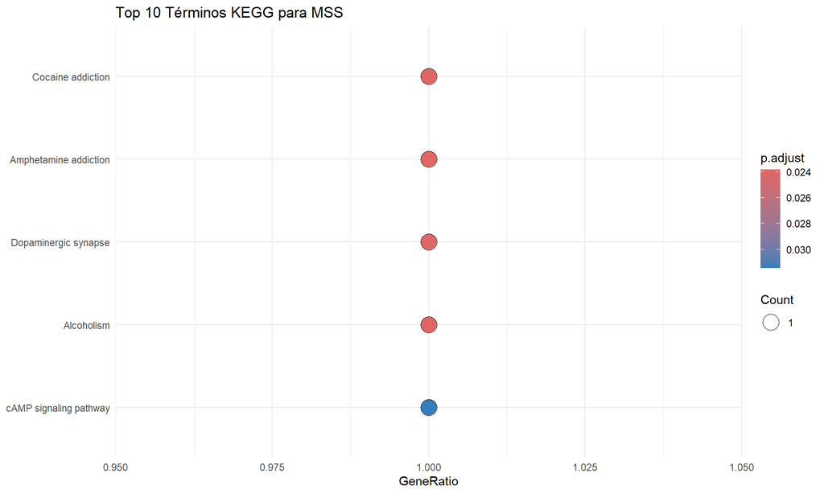

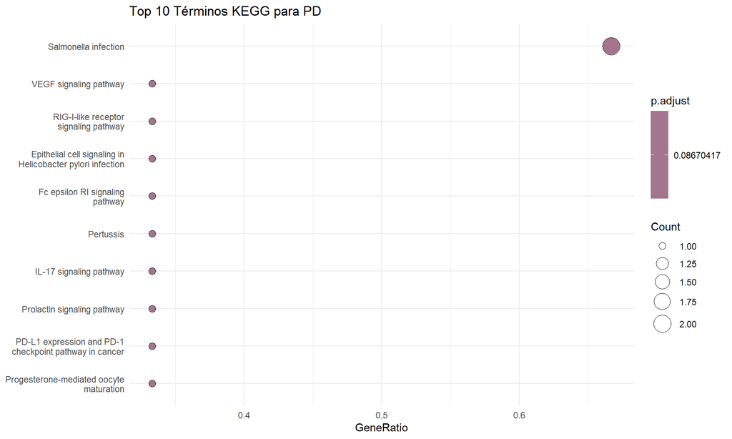

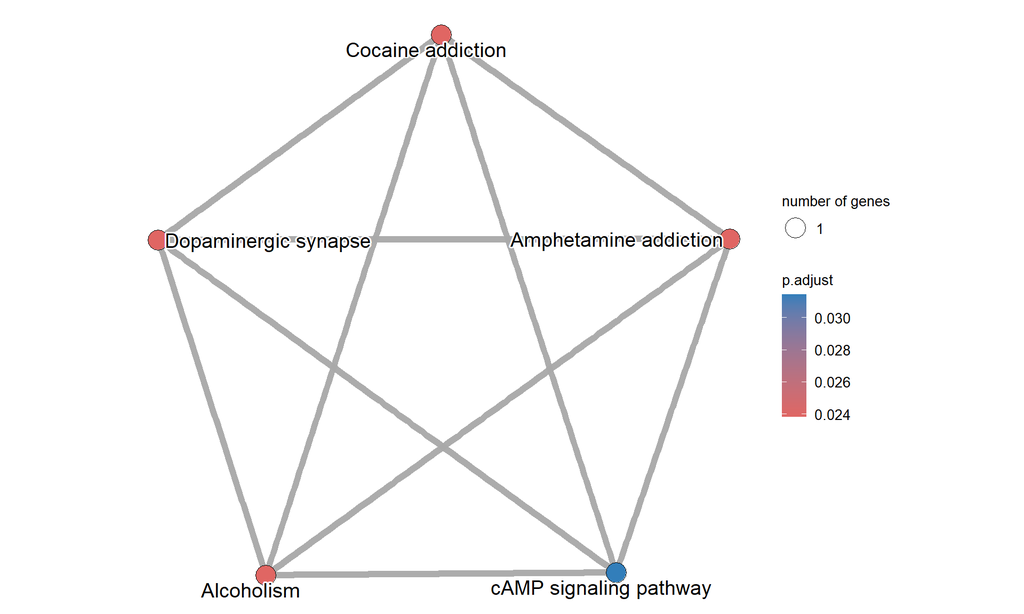

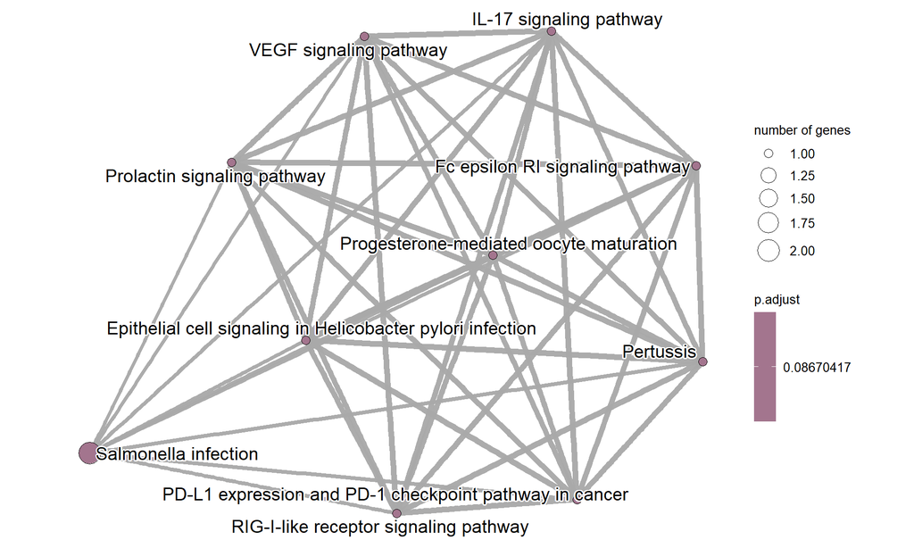

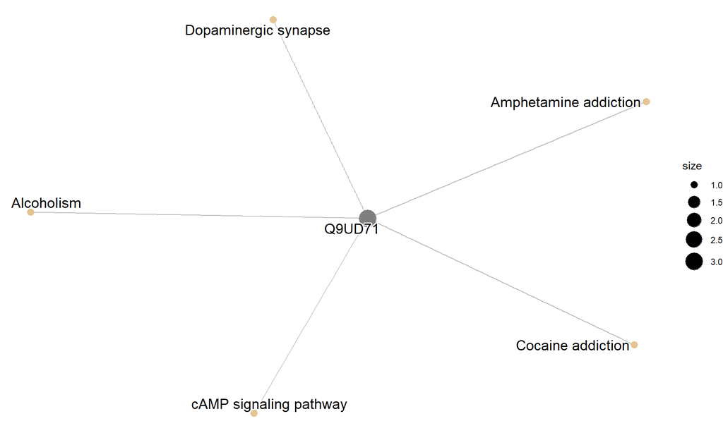

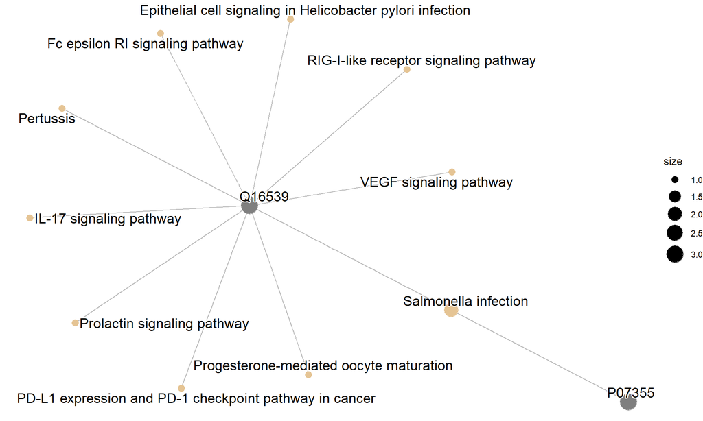

**Interpretación de los resultados**

**Grupo PD**

- **Salmonella Infection** y **Pertussis**: Estas rutas relacionadas con infecciones bacterianas sugieren que las proteínas fosforiladas en PD podrían estar involucradas en respuestas inmunológicas o en la activación de defensas celulares. Este patrón podría estar relacionado con un perfil tumoral que presenta mecanismos de respuesta ante estrés ambiental o agentes infecciosos.
- **VEGF Signaling Pathway**: La vía de señalización del factor de crecimiento endotelial vascular (VEGF) es crítica para la **angiogénesis y el suministro de nutrientes al tumor**. Su presencia sugiere que PD podría estar impulsando el crecimiento y la proliferación tumoral mediante la formación de nuevos vasos sanguíneos.
- **RIG-I-like Receptor Signaling Pathway**: Esta ruta, importante en la respuesta antiviral, apunta a una **activación de mecanismos de detección y respuesta al estrés celular**, típicamente vinculados a la defensa contra virus y células en peligro. En el contexto tumoral, podría indicar una actividad de señalización que favorece la resistencia.
- **PD-L1 Expression and PD-1 Checkpoint Pathway in Cancer**: Esta ruta es clave en la evasión inmune por parte del tumor, lo que sugiere que PD podría aprovechar mecanismos de inhibición de la respuesta inmune para **evadir la detección por el sistema inmunológico**.

En conjunto, estas rutas resaltan un perfil en PD caracterizado por una **proliferación activa, angiogénesis** y mecanismos de **evasión inmune**, lo cual podría favorecer un comportamiento más agresivo y resistente a terapias inmunes.

**Grupo MSS**

En el grupo MSS, las rutas de enriquecimiento están relacionadas principalmente con la señalización neuronal y la adicción a sustancias.

- **Cocaine Addiction, Amphetamine Addiction, y Alcoholism**: Estas rutas están vinculadas a procesos de **señalización dopaminérgica y neuroadaptación**, lo que sugiere que MSS podría activar mecanismos de regulación neuronal o de respuesta al entorno mediante fosforilación en estas vías.
- **Dopaminergic Synapse**: Esta ruta de señalización dopaminérgica, además de estar relacionada con procesos adictivos, está involucrada en la **modulación de la señalización celular** y podría reflejar un comportamiento de MSS orientado a una regulación celular estable.
- **cAMP Signaling Pathway**: Esta ruta de señalización, implicada en la transmisión de señales celulares, podría sugerir que MSS mantiene un perfil homeostático, con capacidad de modular su respuesta a estímulos sin activar mecanismos proliferativos agresivos.

Estas rutas en MSS parecen indicar un perfil menos agresivo, con **mecanismos de señalización orientados a la regulación celular** y una interacción más balanceada con el entorno.

**Conclusión**

##### **Paso 3.2: Análisis de Rutas en Reactome**

Reactome proporciona un análisis detallado de vías de señalización y modificaciones postraduccionales. En nuestro caso, permite identificar cambios críticos en rutas de señalización y su relevancia en el desarrollo tumoral.

```
## Conversiones de UniProt a ENTREZ para PD y MSS:
```

```
##    UNIPROT ENTREZID
## 2   Q5XXA6    55107
## 3   Q9H1C7    84418
## 4   P07355      302
## 5   Q02952     9590
## 7   Q16539     1432
## 12  O60885    23476
```

```
##    UNIPROT ENTREZID
## 1   Q53RY4   200634
## 3   Q12929     2059
## 5   Q9H1E3    64710
## 12  Q9UD71    84152
```

|  | ID | Description | GeneRatio | BgRatio | pvalue | p.adjust | qvalue | geneID | Count |
| --- | --- | --- | --- | --- | --- | --- | --- | --- | --- |
| R-HSA-6798695 | R-HSA-6798695 | Neutrophil degranulation | 3/8 | 480/11091 | 0.0038326139709892 | 0.1024751987916955 | 0.06386958373443624 | 84418/302/1432 | 3 |
| R-HSA-2151209 | R-HSA-2151209 | Activation of PPARGC1A (PGC-1alpha) by phosphorylation | 1/8 | 10/11091 | 0.007192597229035425 | 0.1024751987916955 | 0.06386958373443624 | 1432 | 1 |
| R-HSA-450341 | R-HSA-450341 | Activation of the AP-1 family of transcription factors | 1/8 | 10/11091 | 0.007192597229035425 | 0.1024751987916955 | 0.06386958373443624 | 1432 | 1 |
| R-HSA-171007 | R-HSA-171007 | p38MAPK events | 1/8 | 13/11091 | 0.00934153026635387 | 0.1024751987916955 | 0.06386958373443624 | 1432 | 1 |
| R-HSA-75205 | R-HSA-75205 | Dissolution of Fibrin Clot | 1/8 | 13/11091 | 0.00934153026635387 | 0.1024751987916955 | 0.06386958373443624 | 302 | 1 |
| R-HSA-9733458 | R-HSA-9733458 | Induction of Cell-Cell Fusion | 1/8 | 13/11091 | 0.00934153026635387 | 0.1024751987916955 | 0.06386958373443624 | 55107 | 1 |

|  | ID | Description | GeneRatio | BgRatio | pvalue | p.adjust | qvalue | geneID | Count |
| --- | --- | --- | --- | --- | --- | --- | --- | --- | --- |
| R-HSA-180024 | R-HSA-180024 | DARPP-32 events | 1/2 | 26/11091 | 0.004683201572303286 | 0.01982635495404494 | 0.003478307886674551 | 84152 | 1 |
| R-HSA-9662361 | R-HSA-9662361 | Sensory processing of sound by outer hair cells of the cochlea | 1/2 | 54/11091 | 0.009714356655519674 | 0.01982635495404494 | 0.003478307886674551 | 2059 | 1 |
| R-HSA-9662360 | R-HSA-9662360 | Sensory processing of sound by inner hair cells of the cochlea | 1/2 | 69/11091 | 0.01240437437027042 | 0.01982635495404494 | 0.003478307886674551 | 2059 | 1 |
| R-HSA-9659379 | R-HSA-9659379 | Sensory processing of sound | 1/2 | 76/11091 | 0.01365846392972203 | 0.01982635495404494 | 0.003478307886674551 | 2059 | 1 |
| R-HSA-111885 | R-HSA-111885 | Opioid Signalling | 1/2 | 92/11091 | 0.01652196246170412 | 0.01982635495404494 | 0.003478307886674551 | 84152 | 1 |
| R-HSA-418594 | R-HSA-418594 | G alpha (i) signalling events | 1/2 | 318/11091 | 0.05652422589124395 | 0.05652422589124395 | 0.009916530858112973 | 84152 | 1 |

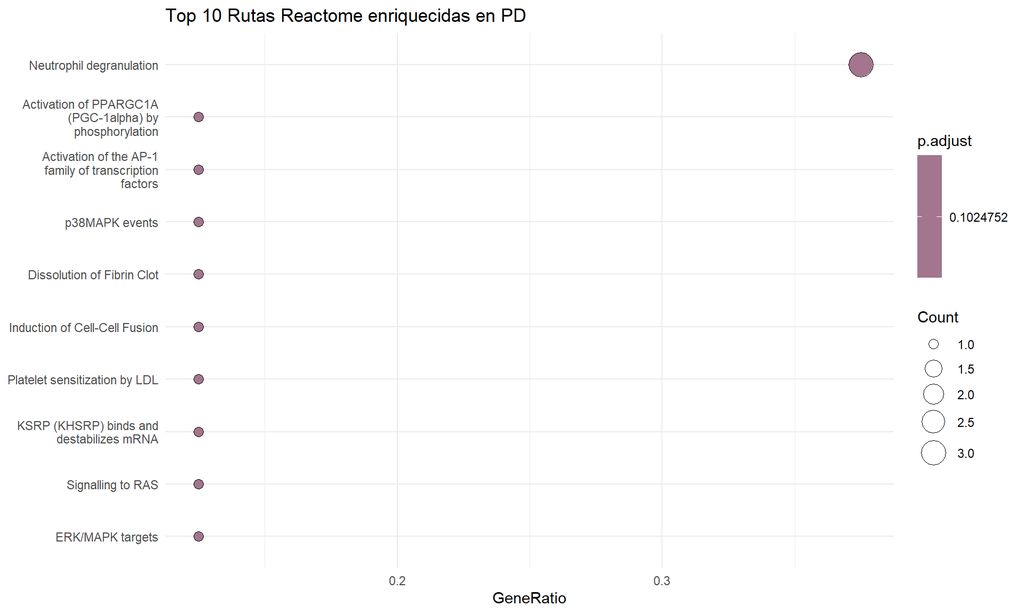

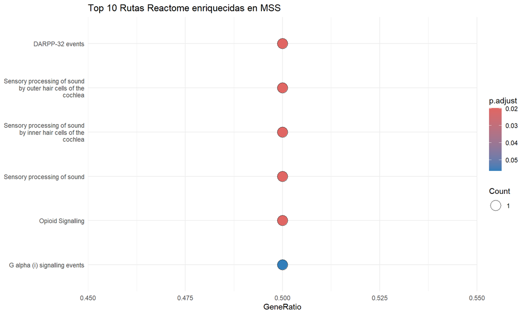

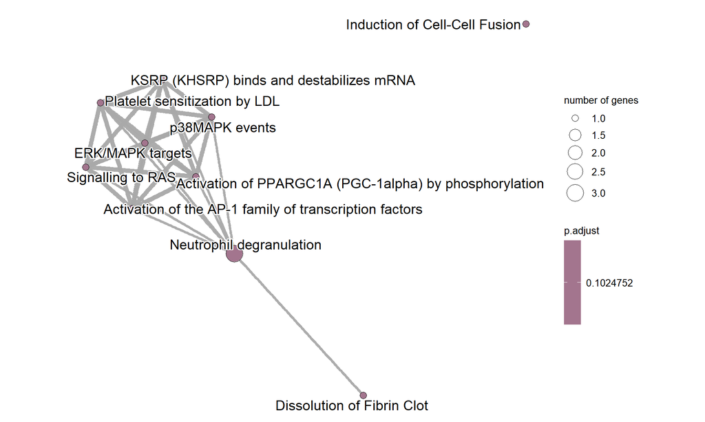

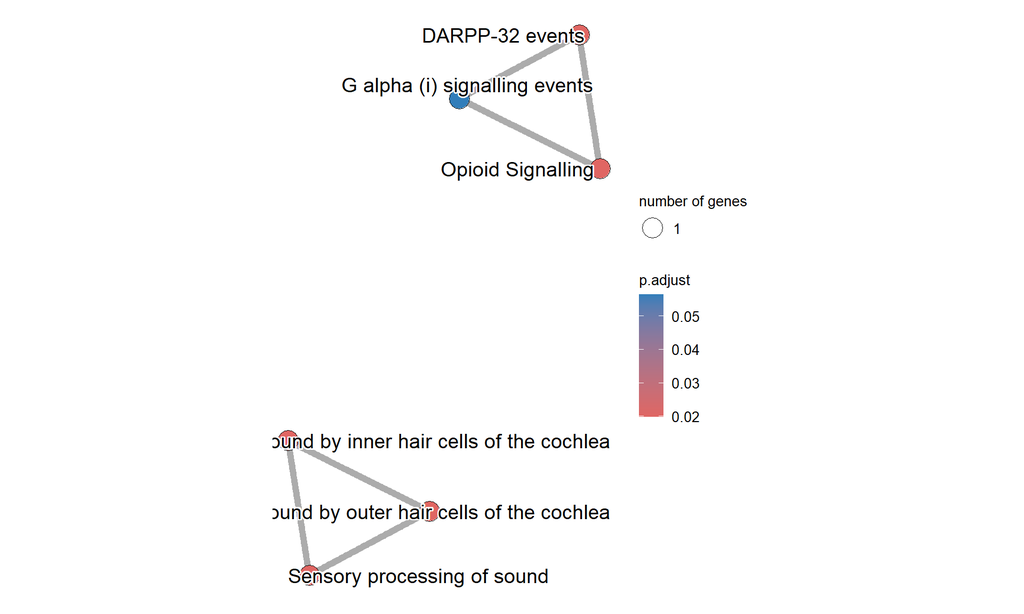

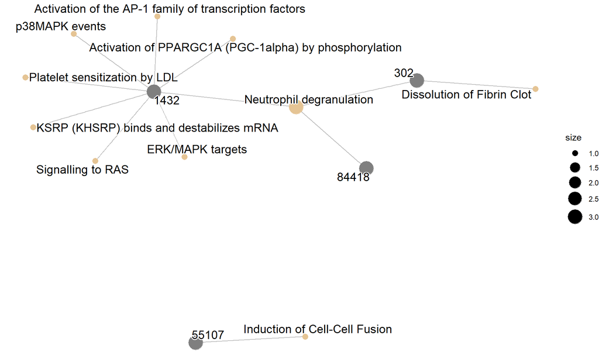

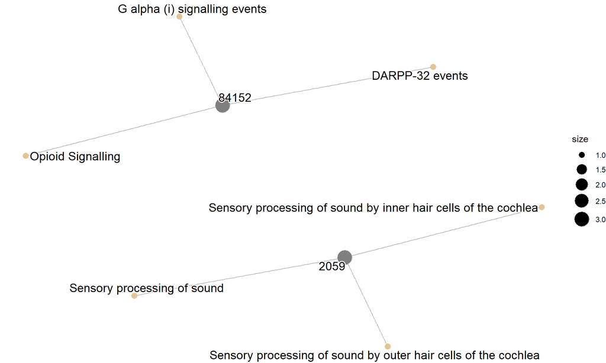

**Interpretación de los resultados**

Los fosfopéptidos más abundantes en PD parecen estar vinculados a rutas de señalización inmunológica, inflamatoria y metabólica, sugiriendo un perfil que apoya la progresión tumoral y la proliferación celular.

2. **Grupo MSS**:
   - **DARPP-32 Events y Opioid Signalling**: Estas rutas de señalización neuronal y de transmisión de señales sugieren una actividad diferente en MSS, posiblemente relacionada con la regulación de rutas de señalización intracelular específicas en este subtipo.
   - **Sensory Processing in Cochlear Hair Cells**: Aunque menos relevante en el contexto tumoral, la presencia de estas rutas podría indicar diferencias en el perfil de señalización entre PD y MSS.
   - **G alpha (i) Signalling Events**: Esta vía de señalización está involucrada en la transmisión de señales a través de proteínas G, indicando potenciales diferencias en la señalización celular en MSS.

En el subtipo MSS, los fosfopéptidos están relacionados principalmente con rutas de señalización neuronal y procesos de transmisión de señales específicos, lo que sugiere un perfil de señalización distinto al de PD.

**Conclusión**

La diferencia clave entre los grupos PD y MSS radica en el tipo de rutas activadas:

##### **Paso 4: Análisis de Redes de Interacción**

El objetivo de este paso es identificar y analizar redes de interacción proteína-proteína (PPI) entre los fosfopéptidos más abundantes en los subtipos tumorales PD y MSS. Esto permite explorar las relaciones funcionales y la organización modular de las proteínas en cada grupo.

**Pasos a seguir:**

1. **Identificación de redes de interacción con STRINGdb**: Se recuperaron redes de interacción proteína-proteína desde STRINGdb para proteínas específicas de cada grupo.
   - **Descripción**: `STRINGdb` es un paquete de R que permite la recuperación de redes de interacción proteína-proteína a partir de la base de datos STRING. Esto permite explorar cómo los fosfopéptidos identificados pueden estar conectados funcionalmente.
   - **Requerimientos**: Debemos asegurarnos de tener los IDs de proteína en un formato compatible con STRING (UniProt o ENTREZ).
2. **Visualización y Análisis de Redes en R con `igraph` o `ggraph`**:
   - Se analizaron las propiedades de las redes y se identificaron módulos o comunidades funcionales mediante algoritmos de clustering.
3. **Priorización de Nodos Clave:**
   - Calculamos métricas de centralidad y grado para destacar proteínas clave en términos de conectividad e intermediación.

```
## Inicializando STRINGdb...
```

```
## WARNING: You didn't specify a version of the STRING database to use. Hence we will use STRING  12.0
```

```
## Mapeando IDs de UniProt a STRING para PD y MSS...
```

```
## IDs no mapeados para PD:
```

```
## [1] UNIPROT   STRING_id
## <0 rows> (o 0- extensión row.names)
```

```
## IDs no mapeados para MSS:
```

```
## [1] UNIPROT   STRING_id
## <0 rows> (o 0- extensión row.names)
```

```
## Obteniendo interacciones para PD y MSS...
```

```
## Creando grafos para PD y MSS...
```

```
## Visualizando red de PD...
```

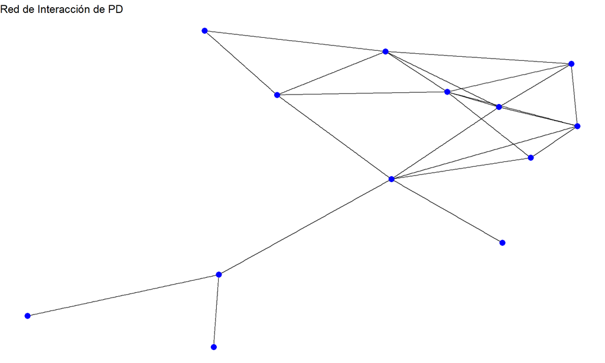

```
## Visualizando red de MSS...
```

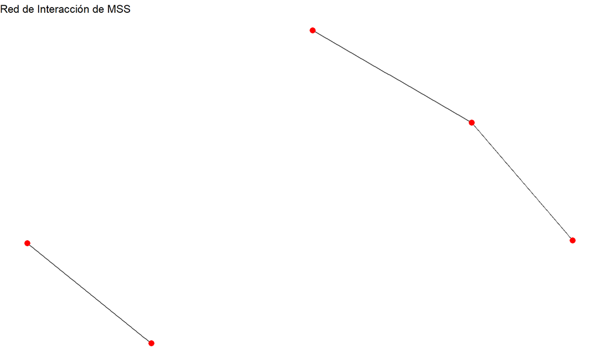

**Interpretación de los resultados**

Los grafos generados para los grupos **PD** y **MSS** muestran las redes de interacción proteína-proteína con el umbral menos estricto implementado.

**Red de Interacción de PD**

- La red muestra una estructura conectada con varios nodos interactuando directamente.
- En el grupo PD, las proteínas parecen participar en un conjunto bien definido de interacciones, lo que podría indicar una funcionalidad centralizada en rutas biológicas específicas. Esto es consistente con un perfil de fosfoproteínas con roles clave en procesos tumorales, como la proliferación, la señalización celular o la angiogénesis.

**Red de Interacción de MSS**

- La red del grupo MSS tiene una estructura más dispersa con pequeños componentes conectados (grupos de 2-3 nodos como máximo).
- La dispersión sugiere una falta de centralización en las interacciones, posiblemente indicando un papel más diversificado o específico de las proteínas en MSS. Esto podría correlacionarse con un perfil tumoral menos agresivo o con interacciones más moduladas en vías relacionadas con la homeostasis celular.

```
##
## Análisis de la red de PD:
```

```
## Detectando comunidades en la red de PD ...
## Número de comunidades en PD : 3
```

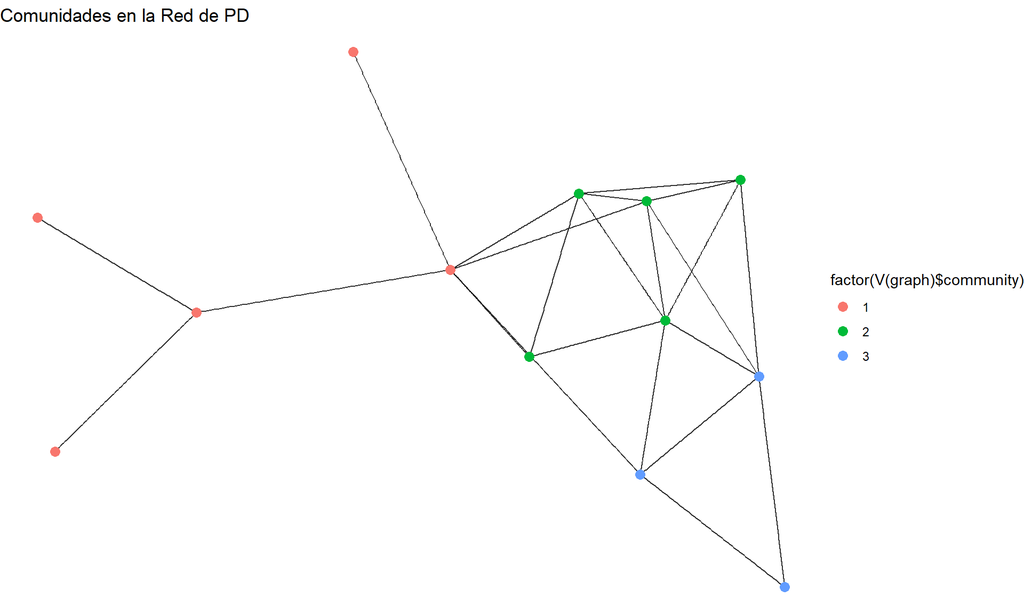

```
## Priorizando proteínas clave en la red de PD ...
## Proteínas con mayor conectividad (grado) en PD :
##  9606.ENSP00000005260 9606.ENSP00000477713 9606.ENSP00000229795 9606.ENSP00000263377 9606.ENSP00000362409
## Proteínas con mayor intermediación (betweenness) en PD :
##  9606.ENSP00000005260 9606.ENSP00000499092 9606.ENSP00000278568 9606.ENSP00000263377 9606.ENSP00000477713
```

```
##
## Análisis de la red de MSS:
```

```
## Detectando comunidades en la red de MSS ...
## Número de comunidades en MSS : 2
```

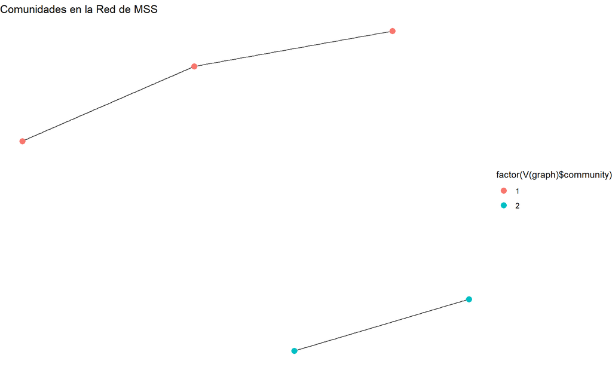

```
## Priorizando proteínas clave en la red de MSS ...
## Proteínas con mayor conectividad (grado) en MSS :
##  9606.ENSP00000410059 9606.ENSP00000217971 9606.ENSP00000301740 9606.ENSP00000356110 9606.ENSP00000273550
## Proteínas con mayor intermediación (betweenness) en MSS :
##  9606.ENSP00000410059 9606.ENSP00000217971 9606.ENSP00000301740 9606.ENSP00000356110 9606.ENSP00000273550
```

```
##
## Comparación entre redes PD y MSS:
```

```
## Densidad de la red PD: 0.2948718
## Densidad de la red MSS: 0.3
```

**Interpretación de los resultados**

**Interpretación de las Redes de Interacción**

**Comparación entre Redes PD y MSS**

1. **Número de comunidades**:
   - La red PD tiene un número mayor de comunidades (3) en comparación con MSS (2). Esto puede sugerir que las proteínas en PD participan en una mayor variedad de procesos funcionales o rutas biológicas.
   - En MSS, la menor cantidad de comunidades y la estructura más dispersa pueden indicar un fenotipo menos heterogéneo en comparación con PD.
2. **Distribución de centralidad**:
   - En PD, las proteínas clave con mayor conectividad e intermediación están más diversificadas. Esto puede estar relacionado con un sistema más dinámico de interacciones.
   - En MSS, las proteínas clave muestran una conectividad más localizada, posiblemente reflejando procesos más específicos y menos integradores.
3. **Densidad**:
   - Las densidades similares (0.29 en PD y 0.3 en MSS) sugieren que ambas redes tienen un nivel comparable de conectividad relativa. Sin embargo, las diferencias en estructura y número de comunidades reflejan diferentes patrones de organización funcional.

**Implicaciones Biológicas**

1. **PD**:
   - Las proteínas con alta conectividad e intermediación pueden ser buenos candidatos para intervenciones terapéuticas, ya que podrían influir significativamente en la red.
   - Las comunidades identificadas podrían representar rutas críticas en la progresión del cáncer en PD, como la proliferación celular, la angiogénesis o la evasión inmune.
2. **MSS**:
   - La estructura más dispersa y el menor número de comunidades sugieren que las proteínas de MSS podrían estar relacionadas con procesos tumorales menos agresivos o más especializados.
   - Las proteínas clave en MSS podrían ser relevantes para entender mecanismos específicos de resistencia tumoral o funciones homeostáticas.

**Limitaciones**:

- Los análisis no incluyen enriquecimiento funcional debido a la ausencia de resultados concretos en este aspecto. Esto limita la interpretación funcional de las comunidades identificadas.
- El uso exclusivo de métricas de centralidad (grado e intermediación) es una aproximación básica que podría complementarse con otros análisis, como modularidad o clustering.

##### **Paso 5:Código para Validación de Biomarcadores**

Este paso tiene como objetivo validar los biomarcadores identificados utilizando bases de datos públicas como **Human Protein Atlas (HPA)** y **PubMed**. Esto permite confirmar la relevancia clínica y científica de los fosfopéptidos en el contexto de su expresión en tejidos específicos y su relación con diferentes tipos de cáncer.

##### **Paso 5.1: Exploración en Human Protein Atlas**

En este análisis, se aprovechan los **UniProt IDs** para consultar su equivalente en **ENSG IDs** utilizando la herramienta **biomaRt**. Esto nos permite extraer información sobre la expresión de las proteínas correspondientes a los fosfopéptidos en tejidos específicos y evaluar su relevancia en distintos tipos de cáncer a través de la base de datos **Human Protein Atlas (HPA)**.

**Pasos a Seguir**

1. Convertimos los **UniProt IDs** a **ENSG IDs** mediante **biomaRt**.
2. Consultamos la base de datos **Human Protein Atlas** utilizando los ENSG IDs obtenidos.
3. Resumimos y estructuramos los resultados en un formato claro y organizado.

```
## Convirtiendo UniProt IDs de PD y MSS a ENSG IDs...
```

```
## Mapeos de PD:
```

```
##    uniprotswissprot ensembl_gene_id
## 1            O60885 ENSG00000141867
## 2            O75494 ENSG00000188529
## 3            P06239 ENSG00000182866
## 4            P07355 ENSG00000182718
## 5            P35611 ENSG00000087274
## 6            Q02952 ENSG00000131016
## 7            Q13153 ENSG00000149269
## 8            Q16539 ENSG00000112062
## 9            Q5XXA6 ENSG00000131620
## 10           Q86SQ4 ENSG00000112414
## 11           Q8TE77 ENSG00000172830
## 12           Q96TA1 ENSG00000136830
## 13           Q9H1C7 ENSG00000120306
## 14           Q9NQ84 ENSG00000291917
## 15           Q9NQ84 ENSG00000170412
## 16           Q9P206 ENSG00000162522
## 17           Q9UHR4 ENSG00000006453
```

```
## Mapeos de MSS:
```

```
##    uniprotswissprot ensembl_gene_id
## 1            O00264 ENSG00000101856
## 2            P02794 ENSG00000167996
## 3            P29692 ENSG00000273594
## 4            P29692 ENSG00000104529
## 5            Q12929 ENSG00000151491
## 6            Q13113 ENSG00000162366
## 7            Q53RY4 ENSG00000157992
## 8            Q9H1E3 ENSG00000069275
## 9            Q9UD71 ENSG00000131771
## 10           Q9UQ35 ENSG00000167978
```

```
## Consultando Human Protein Atlas para PD...
```

```
## Error en la consulta para ENSG00000291917 con código de estado:
```

```
## Consultando Human Protein Atlas para MSS...
```

```
## Error en la consulta para ENSG00000273594 con código de estado:
```

```
##
## Resumen de Human Protein Atlas para PD:
```

[output not shown]

```
##
## Resumen de Human Protein Atlas para MSS:
```

[output not shown]

##### **Paso 5.2: Búsquedas en PubMed**

Este paso emplea la API de Entrez para buscar artículos científicos en **PubMed** que estén relacionados con los biomarcadores identificados. Se utiliza el término de búsqueda generado a partir de los UniProt IDs, buscando su conexión con cáncer y fosforilación.

**Pasos a Seguir**

1. Configuramos la clave API de Entrez, para ello primero nos hemos creado una clave API en NCBI.
2. Realizamos búsquedas en PubMed para los **UniProt IDs** de PD y MSS.
3. Organizamos y mostramos los resultados de las búsquedas.

```
## Clave API configurada correctamente.
```

```
## Buscando en PubMed para PD...
```

```
## Buscando en PubMed para MSS...
```

```
## Resultados de PubMed para PD:
```

[output not shown]

[output cut: 360 more lines]

[output not shown]

```
## Resultados de PubMed para MSS:
```

[output not shown]

[output cut: 178 more lines]

[output not shown]

**Interpretación de los resultados**